# Limited evidence for unique viral tolerance in bats - Hierarchical Models

Maxwell J. Farrell

```r
# Loading data

# experimental data
primary <- read.csv("../raw_data/primary_screen.csv")
speciesonly <- read.csv("../raw_data/species_only_data.csv")
indiv <- read.csv("../raw_data/individual_data.csv")

# re-create column for individualID
indiv <- indiv %>%                              # Create numbering variable
      group_by(PaperID) %>%
        mutate(IndividualID = paste(row_number(),unique(PaperID), sep="_"))

# host data
tree <- read.nexus("../raw_data/upham_tree_666.nex")
tax <- read.csv("../raw_data/taxonomy_mamPhy_5911species.csv")

bats <- tax[tax$ord=="CHIROPTERA",]
rodents <- tax[tax$ord=="RODENTIA",]

bat_tree <- drop.tip(tree, setdiff(tree$tip.label, bats$Species_Name))
rodent_tree <- drop.tip(tree, setdiff(tree$tip.label, rodents$Species_Name))

hosts <- read.csv("../raw_data/HostNames_NCBI_Upham.csv")
hosts$Host_Upham <- gsub(" ", "_", hosts$Host_Upham)

# virus names and taxonomy
vtax <- read.csv("../clean_data/Virus_taxonomy.csv")
viruses <- read.csv("../raw_data/VirusNames_translation_Feb23_2024.csv")
viruses <- left_join(viruses, vtax)

#subset to only host reported and upham
hosts <- hosts %>% select(Host_reported, Host_Upham) %>% unique()

# add names
primary <- dplyr::left_join(primary, viruses)
primary <- dplyr::left_join(primary, hosts)
speciesonly <- dplyr::left_join(speciesonly, viruses)
speciesonly <- dplyr::left_join(speciesonly, hosts)
indiv <- dplyr::left_join(indiv, viruses)
indiv <- dplyr::left_join(indiv, hosts)

# merge speciesonly with individual data
dat <- full_join(indiv, speciesonly)

# removing hosts and viruses with NA names
dat <- dat[!is.na(dat$Virus_ICTV),]
dat <- dat[!is.na(dat$Host_Upham),]

# make subset tree to sampled hosts
host_tree <- drop.tip(tree, setdiff(tree$tip.label, dat$Host_Upham))


# These are models of disease, so remove studies where pathology was not reported
dat <- dplyr::left_join(dat, unique(select(primary, PaperID, Virus_reported, Host_reported, PathologyReported_YN)))
# dim(dat)# 2923
dat <- dat[dat$PathologyReported_YN=="Y",]
# dim(dat)# 2726

# subset to only suscptible individuals / species
dat <- dat[dat$Susceptible_YN=="Y",]
# dim(dat) # 2238

# make virus tree
vtax <- as.data.frame(unclass(vtax), stringsAsFactors=TRUE)
frm <- ~superkingdom/realm/kingdom/phylum/class/order/family/genus/Virus_ICTV
vtree <- as.phylo(frm, data = vtax, collapse=FALSE)
vtree$edge.length <- rep(1, nrow(vtree$edge))

# include only viruses in subset data (e.g. after removing mole)
vtree <- drop.tip(vtree, setdiff(vtree$tip.label, dat$Virus_ICTV))
# plot(vtree)


# add host weight and cleaned dose and inoculation route data
dose_dat <- read.csv("../clean_data/dose_inoculation_data.csv")
dat <- select(dat, -c(Dose_amount, Dose_unit))
dat <- dplyr::left_join(dat, dose_dat)


# adding host specificity data
host_range <- read.csv("../clean_data/host_range_data.csv")

dat <- dplyr::left_join(dat, host_range)
# dim(dat)# 2238
```

# Priors

Visualization of brms default priors (blue) compared to custom priors (yellow) inspired by McElreath’s book Statistical Rethinking.

Priors for the slope parameters:

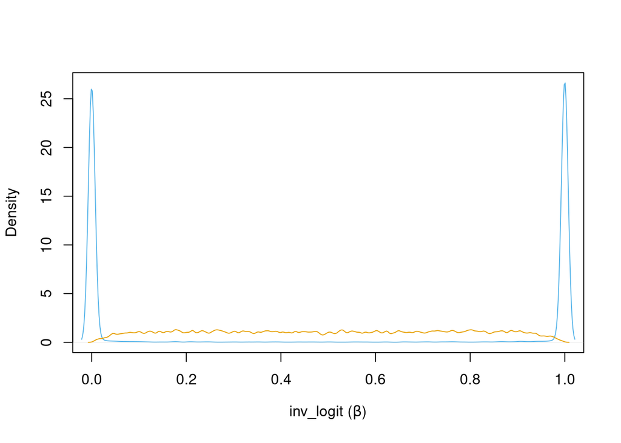

```r
inv_logit <- function(x) {exp(x)/(1+exp(x))}

prior <- runif(n=10000, min=-100, max=100) # brms default is actually -Inf to +Inf
p <- inv_logit(prior)
prior2 <- rnorm(n=10000, 0, 1.5) # McElreath
p2 <- inv_logit(prior2)

plot(density(p, adj=0.1), xlim=c(0,1), col="#56B4E9", main="", xlab=expression(paste("inv_logit (",beta,")")))
lines(density(p2, adj=0.1), col="#E69F00")
```

The default improper uniform prior used by brms is flat on the log-odds scale, so when converted to the probabilty scale, puts excess mass near 0 and 1. A Normal(0, 1.5) prior is more reasonable, having a flatter distribution with a mode at 0.5 on the probablity scale.

Priors for the family-level variance parameters:

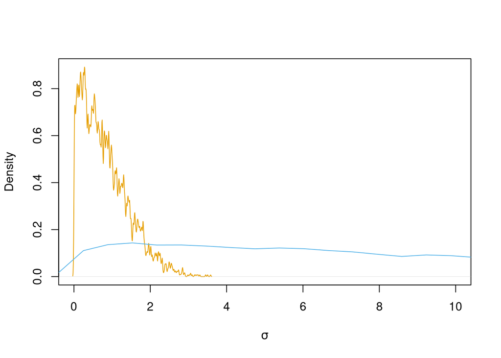

```r
prior <- rstudent_t(n=10000, df=3, mu=0, sigma=10) # brms default
prior <- prior[prior>0]
# p <- inv_logit(prior)

prior2 <- rnorm(n=10000, 0, 1) # McElreath
prior2 <- prior2[prior2>0]
# p2 <- inv_logit(prior2)

plot(density(prior2, adj=0.1), xlim=c(0,10), col="#E69F00", main="", xlab=expression(paste(sigma)))
lines(density(prior, adj=0.1), col="#56B4E9")
```

The brms prior is extremely long tailed. Considering we are fitting a non-linear model in which changes in log-odds over over 4 have a diminishing influence due to the ceiling effect of the binomial distribution. With this in mind, a prior of Normal(0,1) constrains the posterior to a more realistic range, and is likely to improve sampling efficiency.

# Species level models

```r
# create a host-virus-study level dataset
spec <- dat
spec <- spec[spec$Susceptible_YN==1,]
spec <- spec[!is.na(spec$Susceptible_YN),]

spec %>% group_by(PaperID, Virus_ICTV, Host_Upham, Host_order, Reservoir_match, ses_pd, EvoIso) %>% summarise(n_indivID=n_distinct(IndividualID), N_individuals=sum(unique(N_individuals), na.rm=TRUE)) %>% View()

# any disease, maximum severity, any mortality, number of susceptible individuals
spec <- spec %>% group_by(PaperID, Virus_ICTV, Host_Upham, Host_order, Reservoir_match, ses_pd, EvoIso) %>%
                  summarise(n_individuals = sum(
                            c(n_distinct(IndividualID, na.rm=TRUE), unique(N_individuals)), na.rm=TRUE),
                            n_studies = n_distinct(PaperID),
                            Disease_YN=max(Disease_YN, na.rm=TRUE),
                            severity_rank=max(severity_rank, na.rm=TRUE),
                            Mortality_YN=max(Mortality_YN, na.rm=TRUE)) %>% unique()

# for combinations in which mortality was all NA max() returns -Inf
# change this back to NA
spec$Mortality_YN[is.infinite(spec$Mortality_YN)] <- NA

# table(spec$Disease_YN)
# 123/(70+123) # 63.7% of h-v-s combinations reported disease

range(spec$n_individuals, na.rm=TRUE)
# 1 - 492


# additional columns for modelling separate phylo and non-phylo species-level effects
spec$Host_name <- spec$Host_Upham
spec$Virus_name <- spec$Virus_ICTV


# scaling / transform continuous  predictors
spec$ses_pd <- scale_half(spec$ses_pd)
spec$EvoIso <- scale_half(spec$EvoIso)
spec$n_individuals <- scale_half(log(spec$n_individuals))
```

## Presence of disease models

### Presence of disease base model

```r
if (!file.exists("../fit_models/spec_disease_base.rds")) {

  spec_disease_m0 <- brm(Disease_YN ~ Host_order,
    data=spec, family=bernoulli(link = "logit"),
    prior=c(prior(normal(0, 1), class = Intercept),
                  prior(normal(0, 1.5), class = b)),
    iter=2000, thin=1,
    control=list(adapt_delta=0.8, max_treedepth=10), cores=4,
    save_pars=save_pars(all=TRUE))

  saveRDS(spec_disease_m0, "../fit_models/spec_disease_base.rds")

} else { spec_disease_m0 <- readRDS("../fit_models/spec_disease_base.rds")}

model <- spec_disease_m0
# summary(model, prob=0.9)

# save memory
rm(spec_disease_m0)

# pp <- brms::posterior_predict(model)
# ppc_dens_overlay(y=model$data$Disease_YN, pp[1:500, ])

param_tab(model)
```

| Parameter | Mean | CI | CI_low | CI_high | Rhat |
| --- | --- | --- | --- | --- | --- |
| b_Intercept | 0.07 | 0.90 | -0.28 | 0.42 | 1.00 |
| b_Host_orderChiroptera | 1.03 | 0.90 | 0.50 | 1.54 | 1.00 |

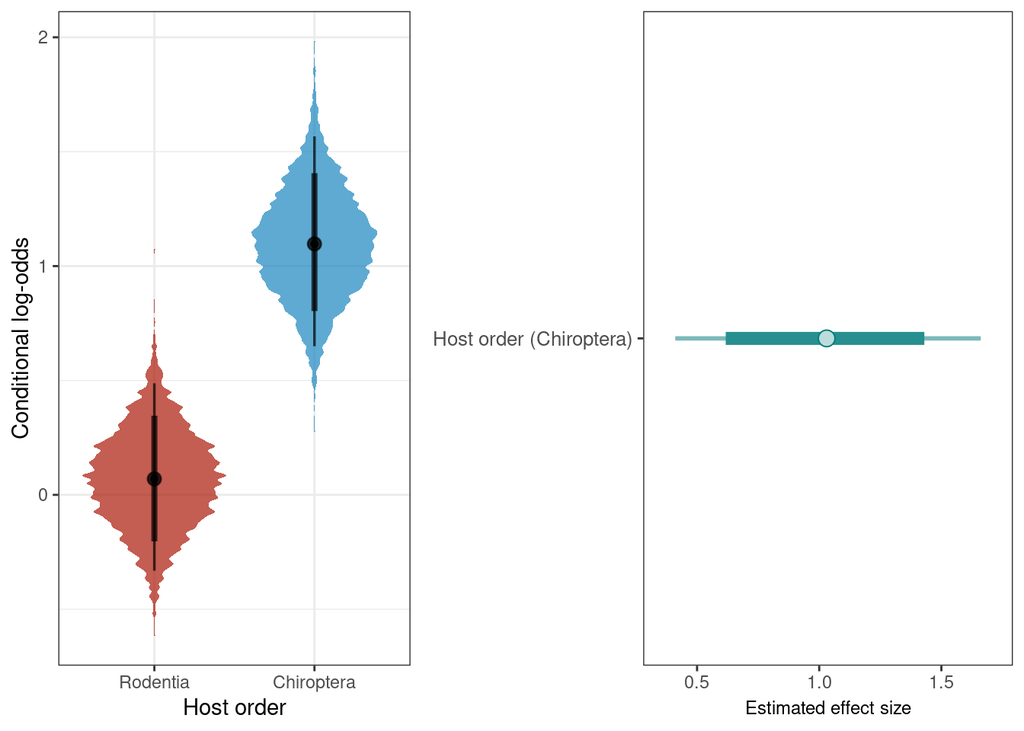

```r
p1 <- cond_eff_plot(model)
ar1 <- intervals_plot(model)
plot_grid(p1, ar1, align="h", rel_widths =c(0.7,1))
```

Sample size: 193

With no hierarchical effects and only the bat/rodent predictor, the model suggests that bats are more likely than rodents to suffer overt disease.

### Presence of disease base model + phylogenetic effects

However, once include hierarchical effects for host and virus species, this effect goes away:

```r
if (!file.exists("../fit_models/spec_disease_base_phylo.rds")) {

  spec_disease_m1 <- brm(Disease_YN ~ Host_order +
                      (1|Host_name) + (1|Virus_name) +
                      (1|Host_Upham) + (1|Virus_ICTV),
    data=spec, family=bernoulli(link = "logit"),
    prior=custom_prior,
    iter=3000, thin=1, cov_ranef = list(Host_Upham = host_cov, Virus_ICTV=virus_cov),
    control=list(adapt_delta=0.8, max_treedepth=12), cores=4,
    save_pars=save_pars(all=TRUE))

  saveRDS(spec_disease_m1, "../fit_models/spec_disease_base_phylo.rds")

} else { spec_disease_m1 <- readRDS("../fit_models/spec_disease_base_phylo.rds")}

model <- spec_disease_m1
# summary(model, prob=0.9)

# save memory
rm(spec_disease_m1)

param_tab(model)
```

| Parameter | Effects | Mean | CI | CI_low | CI_high | Rhat | Group |
| --- | --- | --- | --- | --- | --- | --- | --- |
| b_Intercept | fixed | 0.63 | 0.90 | -0.69 | 1.94 | 1.00 |  |
| b_Host_orderChiroptera | fixed | -0.07 | 0.90 | -1.45 | 1.30 | 1.00 |  |
| sd_Host_name__Intercept | random | 0.55 | 0.90 | 0.04 | 1.34 | 1.00 | Host_name |
| sd_Host_Upham__Intercept | random | 0.81 | 0.90 | 0.07 | 1.76 | 1.00 | Host_Upham |
| sd_Virus_ICTV__Intercept | random | 1.44 | 0.90 | 0.34 | 2.58 | 1.00 | Virus_ICTV |
| sd_Virus_name__Intercept | random | 1.66 | 0.90 | 0.69 | 2.61 | 1.00 | Virus_name |

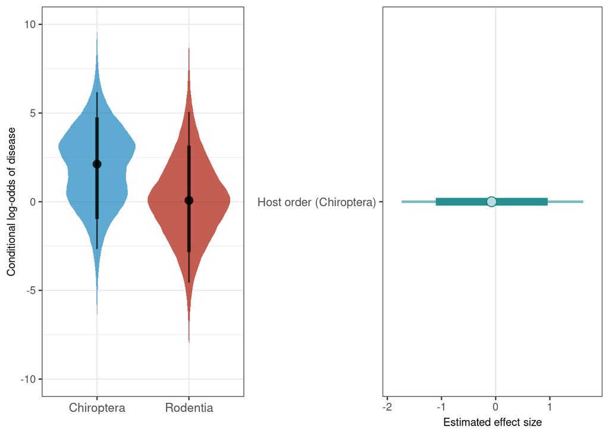

```r
p1 <- cond_eff_plot(model) + scale_y_continuous(lim=c(-10,10)) +
      ylab("Conditional log-odds of disease") + xlab("") +
      theme(axis.title=element_text(size=9),axis.text.x=element_text(size=10)) +
      scale_x_discrete(limits = c("Chiroptera","Rodentia"))

ar1 <- intervals_plot(model)

plot_grid(p1, ar1, align="h", rel_widths =c(0.7,1))
```

```r
ggsave("../plots_tables/base_phylo_species_level_disease_comboplot.pdf", width=8, height=3)
```

Sample size: 193

## Presence of disease full model

```r
if (!file.exists("../fit_models/spec_disease_full.rds")) {

  spec_disease_full <-
        brm(Disease_YN ~ Host_order + n_individuals +
                      ses_pd + EvoIso +
                      (1|PaperID) +
                      (1|Host_name) + (1|Virus_name) +
                      (1|Host_Upham) + (1|Virus_ICTV),
    data=spec, family=bernoulli(link = "logit"),
    prior=custom_prior,
    iter=5000, thin=1, cov_ranef = list(Host_Upham = host_cov, Virus_ICTV=virus_cov),
    control=list(adapt_delta=0.92, max_treedepth=12), cores=4,
    save_pars=save_pars(all=TRUE))

  saveRDS(spec_disease_full, "../fit_models/spec_disease_full.rds")

} else { spec_disease_full <- readRDS("../fit_models/spec_disease_full.rds")}

model <- spec_disease_full
# summary(model, prob=0.9)

# pp <- brms::posterior_predict(model)
# ppc_dens_overlay(y=model$data$Disease_YN, pp[1:500, ])

param_tab(model)
```

| Parameter | Effects | Mean | CI | CI_low | CI_high | Rhat | Group |
| --- | --- | --- | --- | --- | --- | --- | --- |
| b_Intercept | fixed | 0.98 | 0.90 | -0.35 | 2.29 | 1.00 |  |
| b_Host_orderChiroptera | fixed | -9.55e-03 | 0.90 | -1.54 | 1.50 | 1.00 |  |
| b_n_individuals | fixed | 1.27 | 0.90 | 0.06 | 2.47 | 1.00 |  |
| b_ses_pd | fixed | -0.69 | 0.90 | -2.17 | 0.82 | 1.00 |  |
| b_EvoIso | fixed | 0.39 | 0.90 | -0.71 | 1.50 | 1.00 |  |
| sd_Host_name__Intercept | random | 0.57 | 0.90 | 0.05 | 1.37 | 1.00 | Host_name |
| sd_Host_Upham__Intercept | random | 0.80 | 0.90 | 0.07 | 1.82 | 1.00 | Host_Upham |
| sd_PaperID__Intercept | random | 1.74 | 0.90 | 0.92 | 2.64 | 1.00 | PaperID |
| sd_Virus_ICTV__Intercept | random | 1.17 | 0.90 | 0.12 | 2.40 | 1.00 | Virus_ICTV |
| sd_Virus_name__Intercept | random | 1.14 | 0.90 | 0.15 | 2.23 | 1.00 | Virus_name |

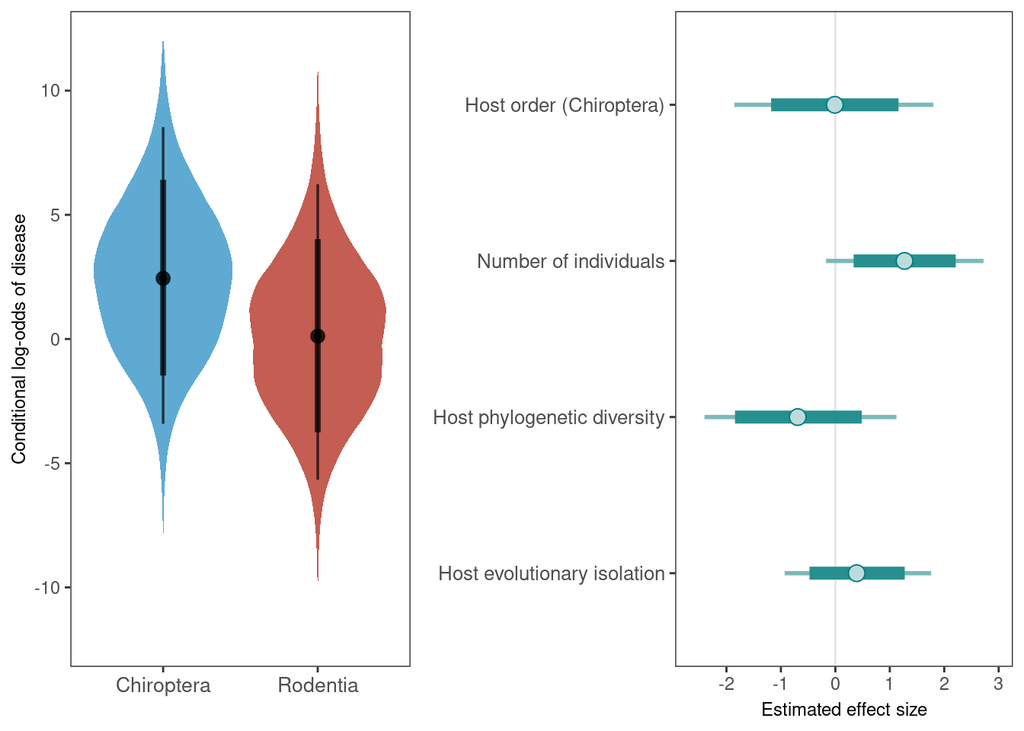

```r
p1 <- cond_eff_plot(model) + scale_y_continuous(lim=c(-12,12)) +
      ylab("Conditional log-odds of disease") + xlab("") +
      theme(axis.title=element_text(size=9),axis.text.x=element_text(size=10),
            panel.grid.major = element_blank(),
            panel.grid.minor = element_blank())+
      scale_x_discrete(limits = c("Chiroptera","Rodentia"))

ar1 <- intervals_plot(model)

plot_grid(p1, ar1, align="h", rel_widths =c(0.7,1))
```

```r
# ggsave("../plots_tables/species_level_disease_full_comboplot.pdf", width=8, height=3)
```

Sample size: 193

## Mortality full model

```r
if (!file.exists("../fit_models/spec_mort_full.rds")) {

  spec_mort_full <-
        brm(Mortality_YN ~ Host_order + n_individuals +
                      ses_pd + EvoIso +
                      (1|PaperID) +
                      (1|Host_name) + (1|Virus_name) +
                      (1|Host_Upham) + (1|Virus_ICTV),
    data=spec, family=bernoulli(link = "logit"),
    prior=custom_prior,
    iter=5000, thin=1, cov_ranef = list(Host_Upham = host_cov, Virus_ICTV=virus_cov),
    control=list(adapt_delta=0.90, max_treedepth=12), cores=4,
    save_pars=save_pars(all=TRUE))

  saveRDS(spec_mort_full, "../fit_models/spec_mort_full.rds")

} else { spec_mort_full <- readRDS("../fit_models/spec_mort_full.rds")}

model <- spec_mort_full
# summary(model, prob=0.9)

# pp <- brms::posterior_predict(model)
# ppc_dens_overlay(y=model$data$Disease_YN, pp[1:500, ])

param_tab(model)
```

| Parameter | Effects | Mean | CI | CI_low | CI_high | Rhat | Group |
| --- | --- | --- | --- | --- | --- | --- | --- |
| b_Intercept | fixed | 0.05 | 0.90 | -1.13 | 1.20 | 1.00 |  |
| b_Host_orderChiroptera | fixed | 0.49 | 0.90 | -1.05 | 2.07 | 1.00 |  |
| b_n_individuals | fixed | 2.34 | 0.90 | 1.00 | 3.71 | 1.00 |  |
| b_ses_pd | fixed | -1.64 | 0.90 | -2.92 | -0.35 | 1.00 |  |
| b_EvoIso | fixed | 1.03 | 0.90 | -0.05 | 2.15 | 1.00 |  |
| sd_Host_name__Intercept | random | 0.75 | 0.90 | 0.07 | 1.66 | 1.00 | Host_name |
| sd_Host_Upham__Intercept | random | 0.93 | 0.90 | 0.12 | 1.93 | 1.00 | Host_Upham |
| sd_PaperID__Intercept | random | 1.27 | 0.90 | 0.33 | 2.19 | 1.00 | PaperID |
| sd_Virus_ICTV__Intercept | random | 0.71 | 0.90 | 0.06 | 1.79 | 1.00 | Virus_ICTV |
| sd_Virus_name__Intercept | random | 0.79 | 0.90 | 0.07 | 1.78 | 1.00 | Virus_name |

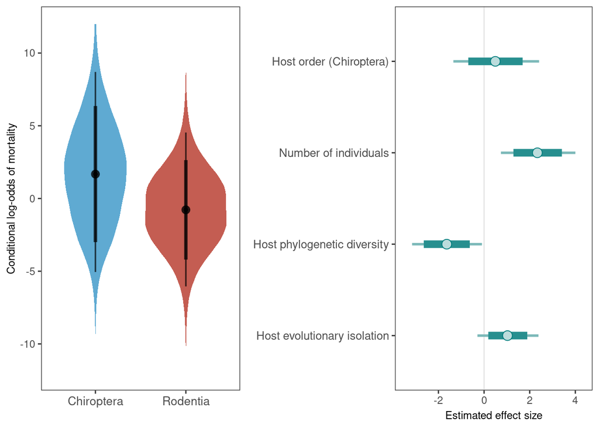

```r
p2 <- cond_eff_plot(model) + scale_y_continuous(lim=c(-12,12)) +
      ylab("Conditional log-odds of mortality") + xlab("") +
      theme(axis.title=element_text(size=9),axis.text.x=element_text(size=10),
            panel.grid.major = element_blank(),
            panel.grid.minor = element_blank())+
      scale_x_discrete(limits = c("Chiroptera","Rodentia"))

ar2 <- intervals_plot(model)

plot_grid(p2, ar2, align="h", rel_widths =c(0.7,1))
```

```r
# ggsave("../plots_tables/species_level_mort_full_comboplot.pdf", width=8, height=3)
```

Sample size: 154

## Severity full model

```r
if (!file.exists("../fit_models/spec_severity_full.rds")) {

  spec_severity_full <-
        brm(severity_rank ~ Host_order + n_individuals +
                      ses_pd + EvoIso +
                      (1|PaperID) +
                      (1|Host_name) + (1|Virus_name) +
                      (1|Host_Upham) + (1|Virus_ICTV),
    data=spec, family=cumulative(probit),
    prior=custom_prior,
    iter=5000, thin=1, cov_ranef = list(Host_Upham = host_cov, Virus_ICTV=virus_cov),
    control=list(adapt_delta=0.95, max_treedepth=14), cores=4,
    save_pars=save_pars(all=TRUE))

  saveRDS(spec_severity_full, "../fit_models/spec_severity_full.rds")

} else { spec_severity_full <- readRDS("../fit_models/spec_severity_full.rds")}

model <- spec_severity_full
# summary(model, prob=0.9)

# pp <- brms::posterior_predict(model)
# ppc_dens_overlay(y=model$data$Disease_YN, pp[1:500, ])

param_tab(model)
```

| Parameter | Effects | Mean | CI | CI_low | CI_high | Rhat | Group |
| --- | --- | --- | --- | --- | --- | --- | --- |
| b_Intercept[1] | fixed | -0.97 | 0.90 | -1.88 | -0.09 | 1.00 |  |
| b_Intercept[2] | fixed | -0.53 | 0.90 | -1.42 | 0.35 | 1.00 |  |
| b_Intercept[3] | fixed | -0.25 | 0.90 | -1.13 | 0.64 | 1.00 |  |
| b_Intercept[4] | fixed | 0.49 | 0.90 | -0.40 | 1.41 | 1.00 |  |
| b_Host_orderChiroptera | fixed | -0.25 | 0.90 | -1.49 | 0.97 | 1.00 |  |
| b_n_individuals | fixed | 1.46 | 0.90 | 0.74 | 2.27 | 1.00 |  |
| b_ses_pd | fixed | -0.66 | 0.90 | -1.65 | 0.32 | 1.00 |  |
| b_EvoIso | fixed | 0.32 | 0.90 | -0.35 | 1.00 | 1.00 |  |
| sd_Host_name__Intercept | random | 0.57 | 0.90 | 0.06 | 1.29 | 1.00 | Host_name |
| sd_Host_Upham__Intercept | random | 0.80 | 0.90 | 0.09 | 1.64 | 1.00 | Host_Upham |
| sd_PaperID__Intercept | random | 0.94 | 0.90 | 0.51 | 1.43 | 1.00 | PaperID |
| sd_Virus_ICTV__Intercept | random | 0.95 | 0.90 | 0.16 | 1.86 | 1.00 | Virus_ICTV |
| sd_Virus_name__Intercept | random | 0.77 | 0.90 | 0.10 | 1.47 | 1.00 | Virus_name |

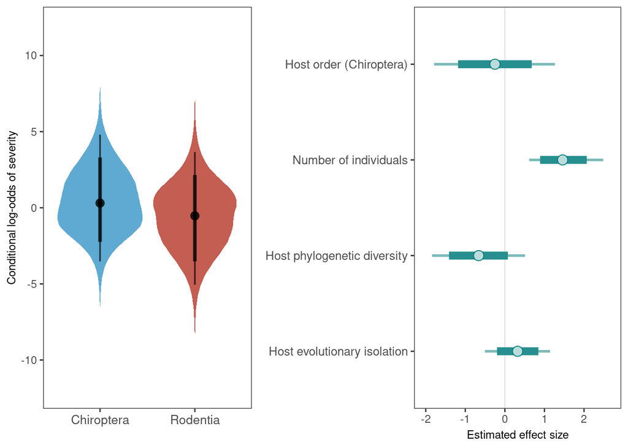

```r
p3 <- cond_eff_plot(model) + scale_y_continuous(lim=c(-12,12)) +
      ylab("Conditional log-odds of severity") + xlab("") +
      theme(axis.title=element_text(size=9),axis.text.x=element_text(size=10),
            panel.grid.major = element_blank(),
            panel.grid.minor = element_blank())+
      scale_x_discrete(limits = c("Chiroptera","Rodentia"))

ar3 <- intervals_plot(model)

plot_grid(p3, ar3, align="h", rel_widths =c(0.7,1))
```

```r
# ggsave("../plots_tables/species_level_severity_full_comboplot.pdf", width=8, height=3)
```

Sample size: 193

## Joint results plots (species level models)

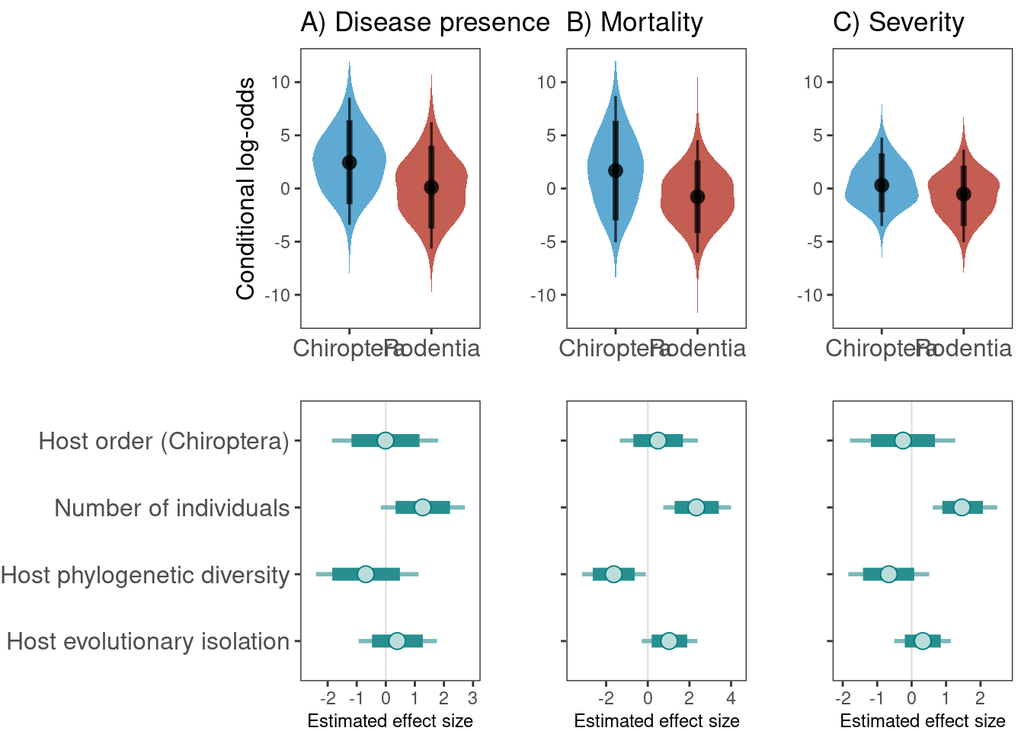

```r
## Joint plot
global_ylim <-  scale_y_continuous(lim=c(-12,12))
padding <- theme(plot.margin = unit(c(t=0, r=-3, b=0, l=0), "cm"))

joint_plot <- joint_conditionals_intervals(p1,p2,p3,global_ylim,padding,ar1,ar2,ar3)
```

```r
ggsave("../plots_tables/species_level_conditionals_intervals_full.pdf", joint_plot, width=10.5, height=5.5)
```

Sample size: 193

## Hierarchical effects plots

### Species level disease full model

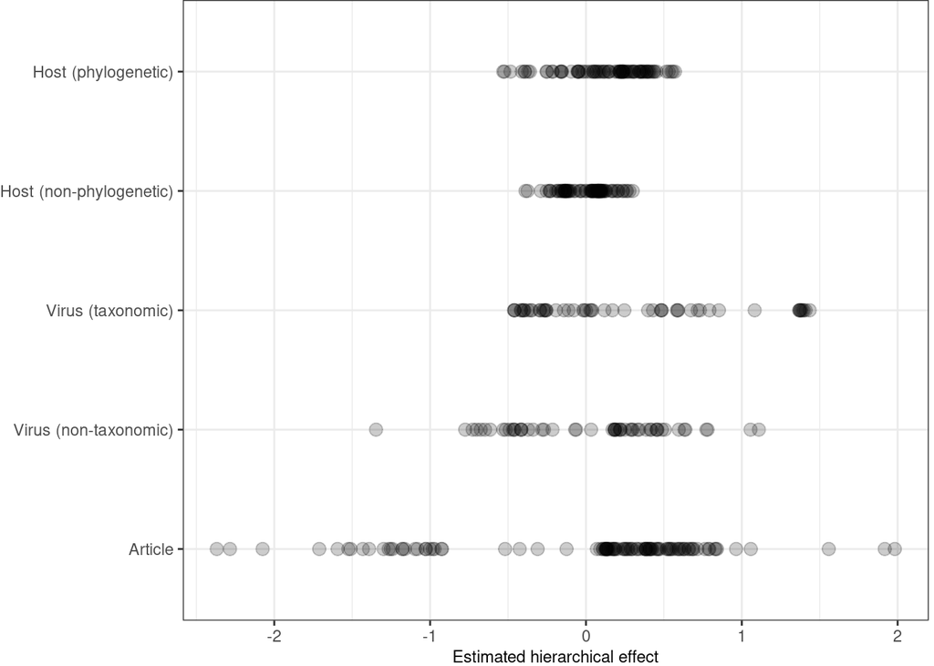

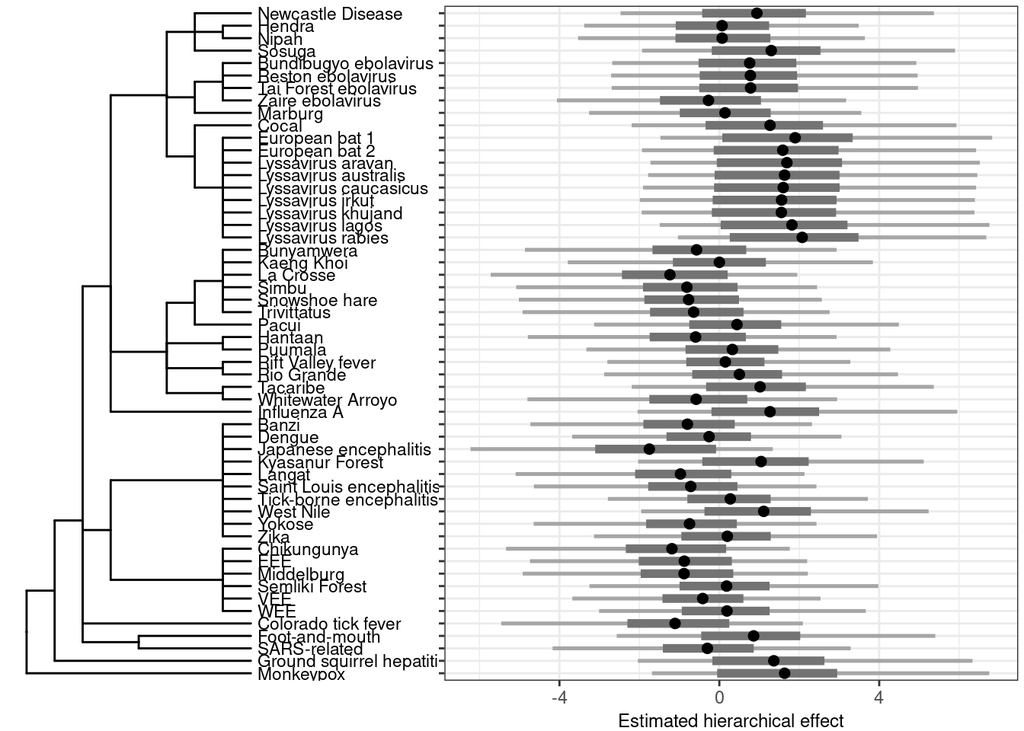

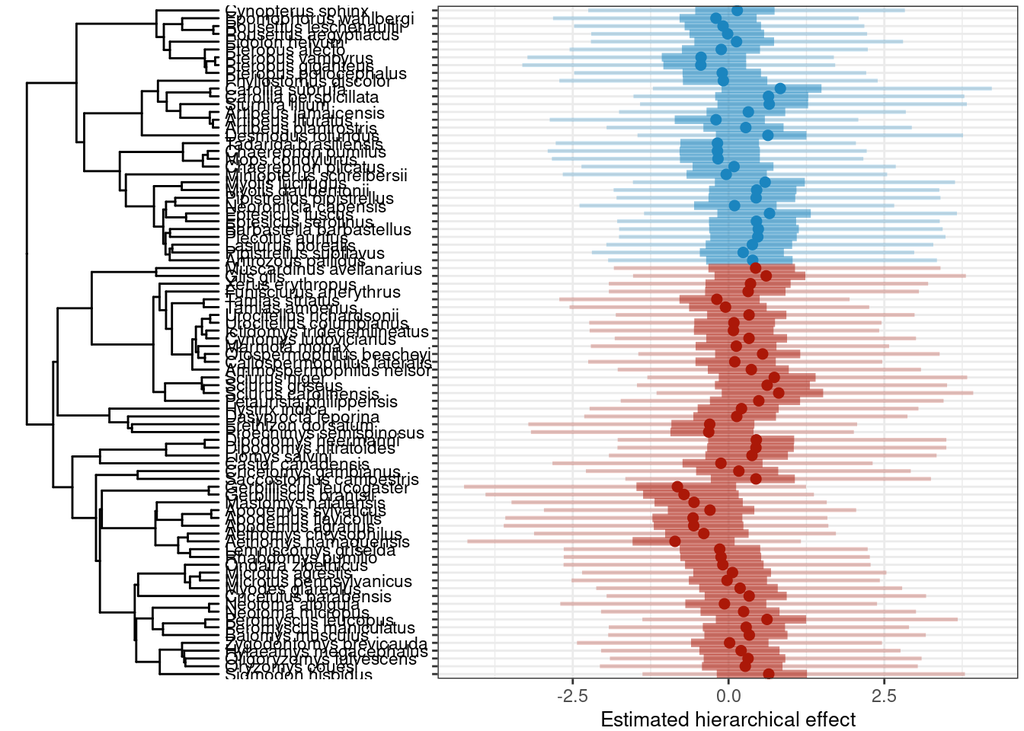

### Species level mortality full model

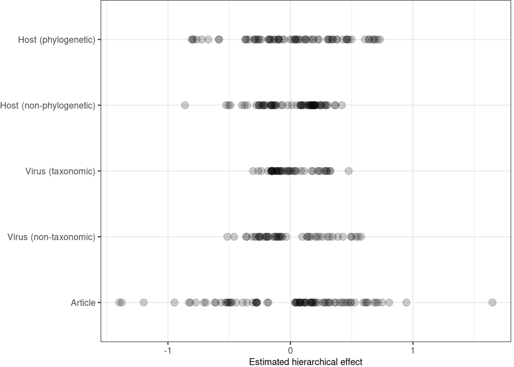

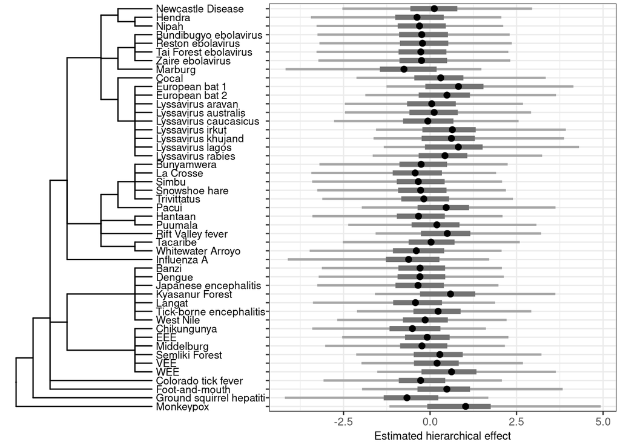

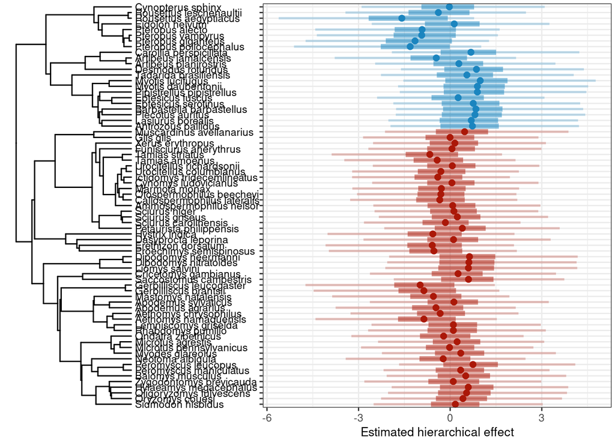

### Species level severity full model

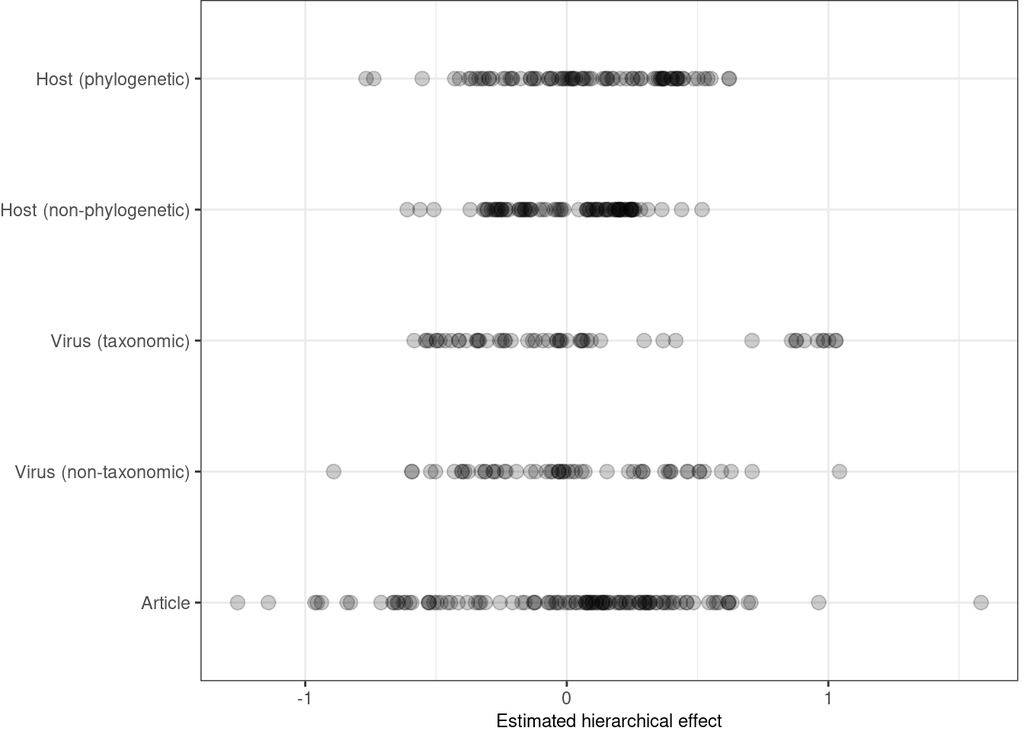

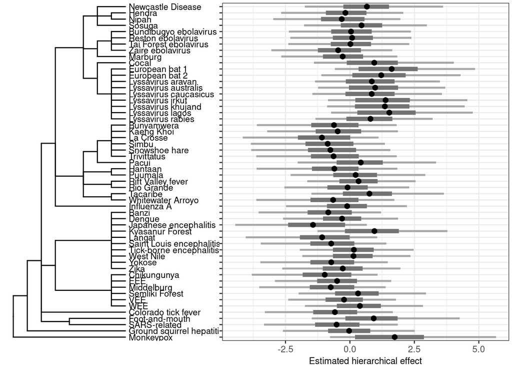

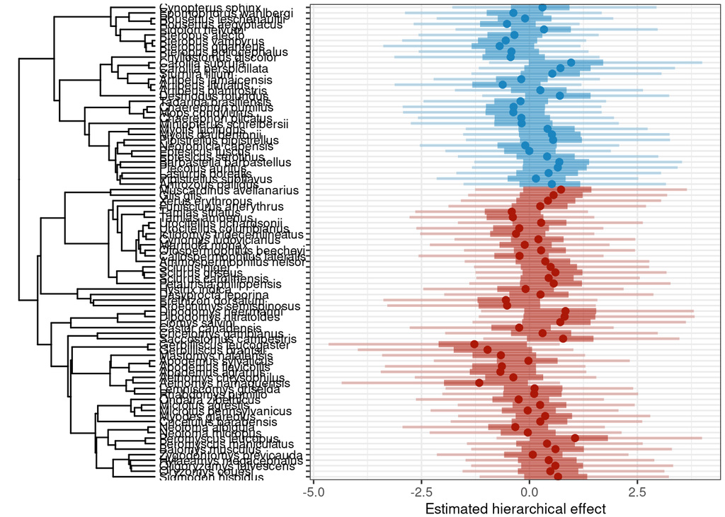

### Joint hierarchical effects plot (species level full model)

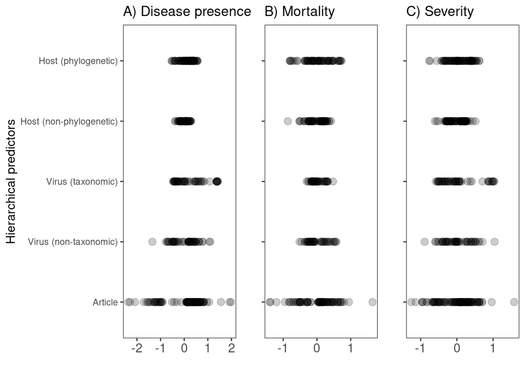

```r
re_all_spec <- egg::ggarrange(
        (re_dis +
        padding +
        ggtitle("A) Disease presence")+
        ylab("Hierarchical predictors") +
        xlab("") +
        theme_bw() +
        theme(legend.position = "none",
              axis.title.y=element_text(size=12),
              axis.text.x=element_text(size=12),
              panel.grid.major = element_blank(),
              panel.grid.minor = element_blank())),

        (re_mort +
        padding +
        ggtitle("B) Mortality")+
        ylab("") +
        xlab("") +
        theme_bw() +
        theme(legend.position = "none",
              axis.text.x=element_text(size=12),
              axis.text.y=element_blank(),
              panel.grid.major = element_blank(),
              panel.grid.minor = element_blank())),

        (re_severity +
        padding +
        ggtitle("C) Severity")+
        ylab("") +
        xlab("") +
        theme_bw() +
        theme(legend.position = "none",
              axis.text.x=element_text(size=12),
              axis.text.y=element_blank(),
              panel.grid.major = element_blank(),
              panel.grid.minor = element_blank())),
        ncol=3, padding=0.5)
```

```r
ggsave("../plots_tables/hierarchical_effects_spec_all.pdf", re_all_spec, width=9, height=4)
```

## Species level models (reservoir match - no HEI)

### Presence of disease (reservoir match - no HEI)

```r
if (!file.exists("../fit_models/spec_disease_resMatch_alone.rds")) {

  spec_disease_resMatch_alone <- brm(Disease_YN ~ Host_order +
                      n_individuals +
                      Reservoir_match +
                      ses_pd +
                      (1|PaperID) +
                      (1|Host_name) + (1|Virus_name) +
                      (1|Host_Upham) + (1|Virus_ICTV),
    data=spec, family=bernoulli(link = "logit"),
    prior=custom_prior,
    iter=5000, thin=1, cov_ranef = list(Host_Upham = host_cov, Virus_ICTV=virus_cov),
    control=list(adapt_delta=0.90, max_treedepth=12), cores=4,
    save_pars=save_pars(all=TRUE))

  saveRDS(spec_disease_resMatch_alone, "../fit_models/spec_disease_resMatch_alone.rds")

} else { spec_disease_resMatch_alone <- readRDS("../fit_models/spec_disease_resMatch_alone.rds")}

model <- spec_disease_resMatch_alone
# summary(model, prob=0.9)

# save memory
rm(spec_disease_resMatch_alone)

# pp <- brms::posterior_predict(model)
# ppc_dens_overlay(y=model$data$Disease_YN, pp[1:500, ])

param_tab(model)
```

| Parameter | Effects | Mean | CI | CI_low | CI_high | Rhat | Group |
| --- | --- | --- | --- | --- | --- | --- | --- |
| b_Intercept | fixed | 1.00 | 0.90 | -0.51 | 2.55 | 1.00 |  |
| b_Host_orderChiroptera | fixed | -0.40 | 0.90 | -1.96 | 1.17 | 1.00 |  |
| b_n_individuals | fixed | 0.93 | 0.90 | -0.18 | 2.07 | 1.00 |  |
| b_Reservoir_match | fixed | 0.04 | 0.90 | -1.29 | 1.35 | 1.00 |  |
| b_ses_pd | fixed | -0.32 | 0.90 | -1.86 | 1.26 | 1.00 |  |
| sd_Host_name__Intercept | random | 0.56 | 0.90 | 0.04 | 1.35 | 1.00 | Host_name |
| sd_Host_Upham__Intercept | random | 0.77 | 0.90 | 0.07 | 1.77 | 1.00 | Host_Upham |
| sd_PaperID__Intercept | random | 1.45 | 0.90 | 0.49 | 2.42 | 1.00 | PaperID |
| sd_Virus_ICTV__Intercept | random | 1.44 | 0.90 | 0.18 | 2.75 | 1.00 | Virus_ICTV |
| sd_Virus_name__Intercept | random | 1.21 | 0.90 | 0.15 | 2.35 | 1.00 | Virus_name |

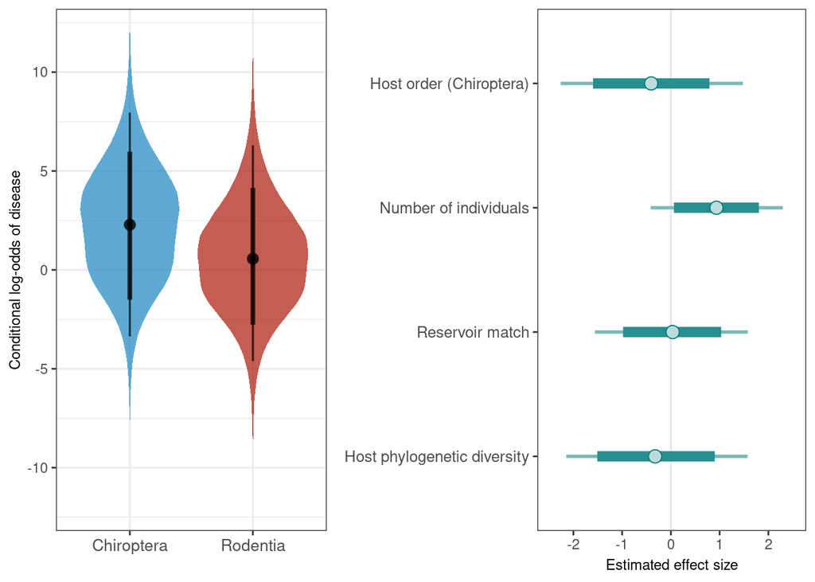

```r
p1 <- cond_eff_plot(model) + scale_y_continuous(lim=c(-12,12)) +
      ylab("Conditional log-odds of disease") + xlab("") +
      theme(axis.title=element_text(size=9),axis.text.x=element_text(size=10)) +
      scale_x_discrete(limits = c("Chiroptera","Rodentia"))

ar1 <- intervals_plot(model)

plot_grid(p1, ar1, align="h", rel_widths =c(0.7,1))
```

```r
# ggsave("../plots_tables/species_level_disease_resMatch_alone_comboplot.pdf", width=8, height=3)
```

Sample size: 176

### Mortality (reservoir match - no HEI)

```r
if (!file.exists("../fit_models/spec_mort_resMatch_alone.rds")) {

  spec_mort_resMatch_alone <- brm(Mortality_YN ~ Host_order +
                      n_individuals +
                      Reservoir_match +
                      ses_pd +
                      (1|PaperID) +
                      (1|Host_name) + (1|Virus_name) +
                      (1|Host_Upham) + (1|Virus_ICTV),
    data=spec, family=bernoulli(link = "logit"),
    prior=custom_prior,
    iter=5000, thin=1, cov_ranef = list(Host_Upham = host_cov, Virus_ICTV=virus_cov),
    control=list(adapt_delta=0.92, max_treedepth=12), cores=4,
    save_pars=save_pars(all=TRUE))

  saveRDS(spec_mort_resMatch_alone, "../fit_models/spec_mort_resMatch_alone.rds")

} else { spec_mort_resMatch_alone <- readRDS("../fit_models/spec_mort_resMatch_alone.rds")}

model <- spec_mort_resMatch_alone
# summary(model, prob=0.90)

# save memory
rm(spec_mort_resMatch_alone)

# pp <- brms::posterior_predict(model)
# ppc_dens_overlay(y=model$data$Mortality_YN, pp[1:500, ])

param_tab(model)
```

| Parameter | Effects | Mean | CI | CI_low | CI_high | Rhat | Group |
| --- | --- | --- | --- | --- | --- | --- | --- |
| b_Intercept | fixed | 0.27 | 0.90 | -1.17 | 1.68 | 1.00 |  |
| b_Host_orderChiroptera | fixed | 0.40 | 0.90 | -1.21 | 1.99 | 1.00 |  |
| b_n_individuals | fixed | 1.86 | 0.90 | 0.61 | 3.14 | 1.00 |  |
| b_Reservoir_match | fixed | -0.53 | 0.90 | -1.82 | 0.74 | 1.00 |  |
| b_ses_pd | fixed | -1.57 | 0.90 | -3.00 | -0.11 | 1.00 |  |
| sd_Host_name__Intercept | random | 0.75 | 0.90 | 0.06 | 1.72 | 1.00 | Host_name |
| sd_Host_Upham__Intercept | random | 0.98 | 0.90 | 0.11 | 1.98 | 1.00 | Host_Upham |
| sd_PaperID__Intercept | random | 1.20 | 0.90 | 0.25 | 2.17 | 1.00 | PaperID |
| sd_Virus_ICTV__Intercept | random | 0.86 | 0.90 | 0.07 | 2.06 | 1.00 | Virus_ICTV |
| sd_Virus_name__Intercept | random | 0.98 | 0.90 | 0.10 | 2.08 | 1.00 | Virus_name |

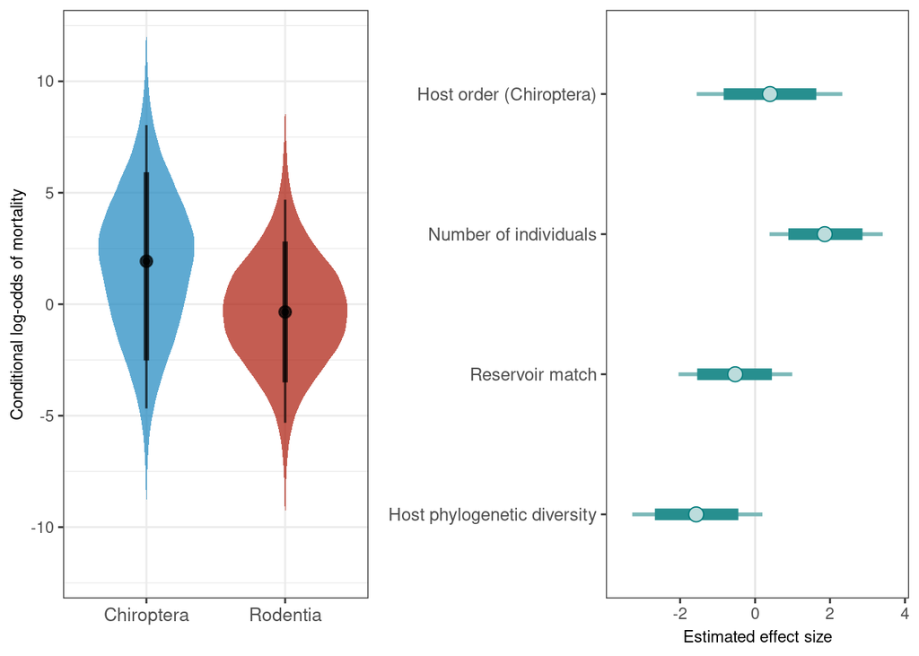

```r
p2 <- cond_eff_plot(model) + scale_y_continuous(lim=c(-12,12)) +
      ylab("Conditional log-odds of mortality") + xlab("") +
      theme(axis.title=element_text(size=9),axis.text.x=element_text(size=10)) +
      scale_x_discrete(limits = c("Chiroptera","Rodentia"))

ar2 <- intervals_plot(model)

plot_grid(p2, ar2, align="h", rel_widths =c(0.7,1))
```

```r
# ggsave("../plots_tables/species_level_mortality_resMatch_alone_comboplot.pdf", width=8, height=3)
```

Sample size: 139

### Severity (reservoir match - no HEI)

```r
if (!file.exists("../fit_models/spec_severity_resMatch_alone.rds")) {

  spec_severity_resMatch_alone <- brm(severity_rank ~ Host_order +
                      n_individuals +
                      Reservoir_match +
                      ses_pd +
                      (1|PaperID) +
                      (1|Host_name) + (1|Virus_name) +
                      (1|Host_Upham) + (1|Virus_ICTV),
    data=spec, family=cumulative(probit),
    prior=custom_prior,
    iter=5000, thin=1, cov_ranef = list(Host_Upham = host_cov, Virus_ICTV=virus_cov),
    control=list(adapt_delta=0.99, max_treedepth=12), cores=4,
    save_pars=save_pars(all=TRUE))

  saveRDS(spec_severity_resMatch_alone, "../fit_models/spec_severity_resMatch_alone.rds")

} else { spec_severity_resMatch_alone <- readRDS("../fit_models/spec_severity_resMatch_alone.rds")}

model <- spec_severity_resMatch_alone
# summary(model, prob=0.90)

# save memory
rm(spec_severity_resMatch_alone)

# pp <- brms::posterior_predict(model)
# ppc_dens_overlay(y=model$data$severity_rank, pp[1:500, ])

param_tab(model)
```

| Parameter | Effects | Mean | CI | CI_low | CI_high | Rhat | Group |
| --- | --- | --- | --- | --- | --- | --- | --- |
| b_Intercept[1] | fixed | -1.04 | 0.90 | -2.15 | 0.04 | 1.00 |  |
| b_Intercept[2] | fixed | -0.70 | 0.90 | -1.78 | 0.37 | 1.00 |  |
| b_Intercept[3] | fixed | -0.39 | 0.90 | -1.46 | 0.67 | 1.00 |  |
| b_Intercept[4] | fixed | 0.37 | 0.90 | -0.70 | 1.46 | 1.00 |  |
| b_Host_orderChiroptera | fixed | -0.41 | 0.90 | -1.65 | 0.86 | 1.00 |  |
| b_n_individuals | fixed | 1.28 | 0.90 | 0.58 | 2.07 | 1.00 |  |
| b_Reservoir_match | fixed | -0.15 | 0.90 | -1.05 | 0.73 | 1.00 |  |
| b_ses_pd | fixed | -0.38 | 0.90 | -1.45 | 0.71 | 1.00 |  |
| sd_Host_name__Intercept | random | 0.61 | 0.90 | 0.06 | 1.36 | 1.00 | Host_name |
| sd_Host_Upham__Intercept | random | 0.79 | 0.90 | 0.10 | 1.65 | 1.00 | Host_Upham |
| sd_PaperID__Intercept | random | 0.90 | 0.90 | 0.43 | 1.40 | 1.00 | PaperID |
| sd_Virus_ICTV__Intercept | random | 1.12 | 0.90 | 0.18 | 2.12 | 1.00 | Virus_ICTV |
| sd_Virus_name__Intercept | random | 0.89 | 0.90 | 0.13 | 1.67 | 1.00 | Virus_name |

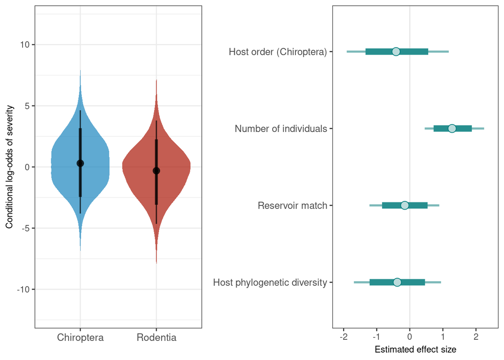

```r
p3 <- cond_eff_plot(model) + scale_y_continuous(lim=c(-12,12)) +
      ylab("Conditional log-odds of severity") + xlab("") +
      theme(axis.title=element_text(size=9),axis.text.x=element_text(size=10)) +
      scale_x_discrete(limits = c("Chiroptera","Rodentia"))

ar3 <- intervals_plot(model)

plot_grid(p3, ar3, align="h", rel_widths =c(0.7,1))
```

```r
# ggsave("../plots_tables/species_level_severity_resMatch_comboplot.pdf", width=8, height=3)
```

Sample size: 176

### Joint results plots (species level reservoir match models - no HEI)

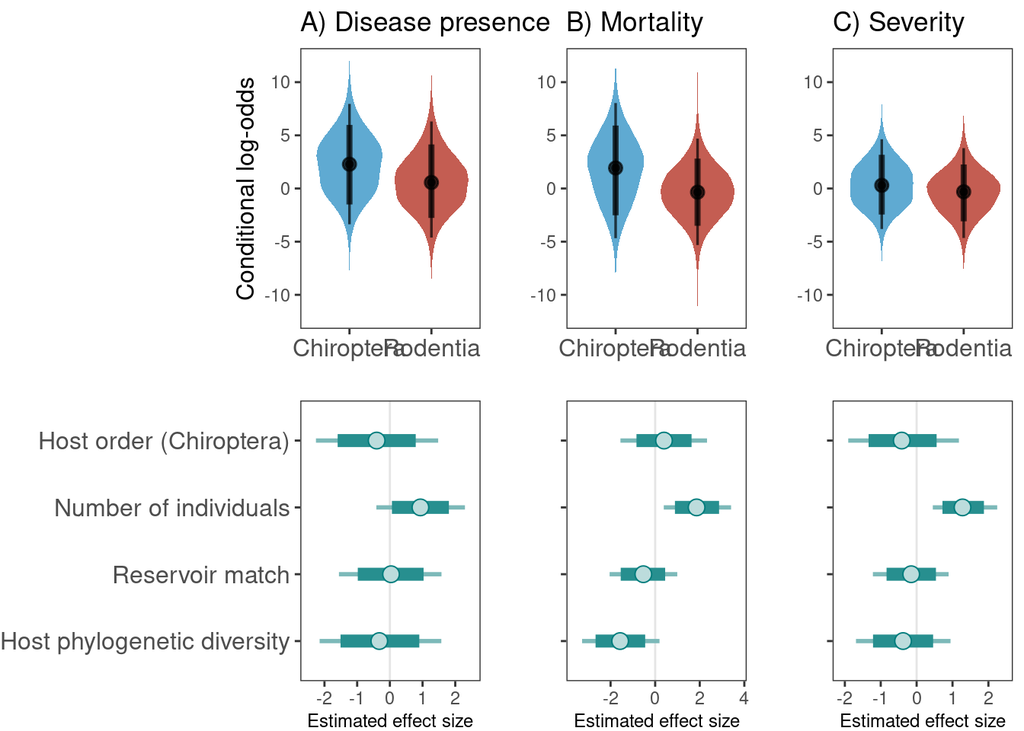

```r
## Joint plot
global_ylim <-  scale_y_continuous(lim=c(-12,12))
padding <- theme(plot.margin = unit(c(t=0, r=-3, b=0, l=0), "cm"))

joint_plot <- joint_conditionals_intervals(p1,p2,p3,global_ylim,padding,ar1,ar2,ar3)
```

```r
ggsave("../plots_tables/species_level_conditionals_intervals_resMatch_alone.pdf", joint_plot, width=10.5, height=5.5)
```

Sample size: 176

## Species level models (reservoir match - with HEI)

### Presence of disease (reservoir match - with HEI)

```r
if (!file.exists("../fit_models/spec_disease_resMatch.rds")) {

  spec_disease_resMatch <- brm(Disease_YN ~ Host_order + n_individuals +
                      Reservoir_match + ses_pd + EvoIso +
                      (1|PaperID) +
                      (1|Host_name) + (1|Virus_name) +
                      (1|Host_Upham) + (1|Virus_ICTV),
    data=spec, family=bernoulli(link = "logit"),
    prior=custom_prior,
    iter=5000, thin=1, cov_ranef = list(Host_Upham = host_cov, Virus_ICTV=virus_cov),
    control=list(adapt_delta=0.90, max_treedepth=12), cores=4,
    save_pars=save_pars(all=TRUE))

  saveRDS(spec_disease_resMatch, "../fit_models/spec_disease_resMatch.rds")

} else { spec_disease_resMatch <- readRDS("../fit_models/spec_disease_resMatch.rds")}

model <- spec_disease_resMatch
# summary(model, prob=0.9)

# save memory
rm(spec_disease_resMatch)

# pp <- brms::posterior_predict(model)
# ppc_dens_overlay(y=model$data$Disease_YN, pp[1:500, ])

param_tab(model)
```

| Parameter | Effects | Mean | CI | CI_low | CI_high | Rhat | Group |
| --- | --- | --- | --- | --- | --- | --- | --- |
| b_Intercept | fixed | 1.01 | 0.90 | -0.53 | 2.58 | 1.00 |  |
| b_Host_orderChiroptera | fixed | -0.43 | 0.90 | -1.96 | 1.13 | 1.00 |  |
| b_n_individuals | fixed | 0.97 | 0.90 | -0.15 | 2.13 | 1.00 |  |
| b_Reservoir_match | fixed | 0.08 | 0.90 | -1.31 | 1.44 | 1.00 |  |
| b_ses_pd | fixed | -0.29 | 0.90 | -1.85 | 1.30 | 1.00 |  |
| b_EvoIso | fixed | 0.26 | 0.90 | -0.92 | 1.41 | 1.00 |  |
| sd_Host_name__Intercept | random | 0.58 | 0.90 | 0.05 | 1.41 | 1.00 | Host_name |
| sd_Host_Upham__Intercept | random | 0.79 | 0.90 | 0.07 | 1.82 | 1.00 | Host_Upham |
| sd_PaperID__Intercept | random | 1.45 | 0.90 | 0.43 | 2.43 | 1.00 | PaperID |
| sd_Virus_ICTV__Intercept | random | 1.50 | 0.90 | 0.23 | 2.81 | 1.00 | Virus_ICTV |
| sd_Virus_name__Intercept | random | 1.21 | 0.90 | 0.15 | 2.35 | 1.00 | Virus_name |

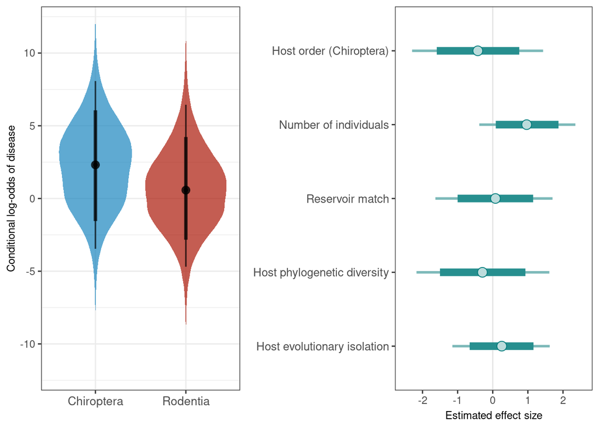

```r
p1 <- cond_eff_plot(model) + scale_y_continuous(lim=c(-12,12)) +
      ylab("Conditional log-odds of disease") + xlab("") +
      theme(axis.title=element_text(size=9),axis.text.x=element_text(size=10)) +
      scale_x_discrete(limits = c("Chiroptera","Rodentia"))

ar1 <- intervals_plot(model)

plot_grid(p1, ar1, align="h", rel_widths =c(0.7,1))
```

```r
# ggsave("../plots_tables/species_level_disease_resMatch_comboplot.pdf", width=8, height=3)
```

Sample size: 176

### Mortality (reservoir match - with HEI)

```r
if (!file.exists("../fit_models/spec_mort_resMatch.rds")) {

  spec_mort_resMatch <- brm(Mortality_YN ~ Host_order + n_individuals +
                      Reservoir_match + ses_pd + EvoIso +
                      (1|PaperID) +
                      (1|Host_name) + (1|Virus_name) +
                      (1|Host_Upham) + (1|Virus_ICTV),
    data=spec, family=bernoulli(link = "logit"),
    prior=custom_prior,
    iter=5000, thin=1, cov_ranef = list(Host_Upham = host_cov, Virus_ICTV=virus_cov),
    control=list(adapt_delta=0.90, max_treedepth=12), cores=4,
    save_pars=save_pars(all=TRUE))

  saveRDS(spec_mort_resMatch, "../fit_models/spec_mort_resMatch.rds")

} else { spec_mort_resMatch <- readRDS("../fit_models/spec_mort_resMatch.rds")}

model <- spec_mort_resMatch
# summary(model, prob=0.90)

# save memory
rm(spec_mort_resMatch)

# pp <- brms::posterior_predict(model)
# ppc_dens_overlay(y=model$data$Mortality_YN, pp[1:500, ])

param_tab(model)
```

| Parameter | Effects | Mean | CI | CI_low | CI_high | Rhat | Group |
| --- | --- | --- | --- | --- | --- | --- | --- |
| b_Intercept | fixed | 0.13 | 0.90 | -1.29 | 1.54 | 1.00 |  |
| b_Host_orderChiroptera | fixed | 0.47 | 0.90 | -1.15 | 2.11 | 1.00 |  |
| b_n_individuals | fixed | 2.09 | 0.90 | 0.80 | 3.44 | 1.00 |  |
| b_Reservoir_match | fixed | -0.20 | 0.90 | -1.56 | 1.14 | 1.00 |  |
| b_ses_pd | fixed | -1.38 | 0.90 | -2.83 | 0.10 | 1.00 |  |
| b_EvoIso | fixed | 0.95 | 0.90 | -0.25 | 2.17 | 1.00 |  |
| sd_Host_name__Intercept | random | 0.75 | 0.90 | 0.06 | 1.73 | 1.00 | Host_name |
| sd_Host_Upham__Intercept | random | 0.97 | 0.90 | 0.13 | 1.96 | 1.00 | Host_Upham |
| sd_PaperID__Intercept | random | 1.22 | 0.90 | 0.27 | 2.16 | 1.00 | PaperID |
| sd_Virus_ICTV__Intercept | random | 0.81 | 0.90 | 0.06 | 1.95 | 1.00 | Virus_ICTV |
| sd_Virus_name__Intercept | random | 0.94 | 0.90 | 0.09 | 2.01 | 1.00 | Virus_name |

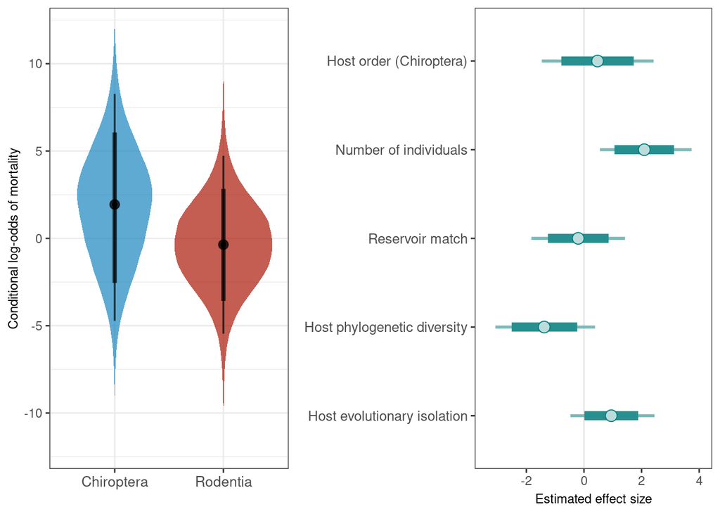

```r
p2 <- cond_eff_plot(model) + scale_y_continuous(lim=c(-12,12)) +
      ylab("Conditional log-odds of mortality") + xlab("") +
      theme(axis.title=element_text(size=9),axis.text.x=element_text(size=10)) +
      scale_x_discrete(limits = c("Chiroptera","Rodentia"))

ar2 <- intervals_plot(model)

plot_grid(p2, ar2, align="h", rel_widths =c(0.7,1))
```

```r
# ggsave("../plots_tables/species_level_mortality_resMatch_comboplot.pdf", width=8, height=3)
```

Sample size: 139

### Severity (reservoir match - with HEI)

```r
if (!file.exists("../fit_models/spec_severity_resMatch.rds")) {

  spec_severity_resMatch <- brm(severity_rank ~ Host_order + n_individuals +
                      Reservoir_match + ses_pd + EvoIso +
                      (1|PaperID) +
                      (1|Host_name) + (1|Virus_name) +
                      (1|Host_Upham) + (1|Virus_ICTV),
    data=spec, family=cumulative(probit),
    prior=custom_prior,
    iter=5000, thin=1, cov_ranef = list(Host_Upham = host_cov, Virus_ICTV=virus_cov),
    control=list(adapt_delta=0.95, max_treedepth=12), cores=4,
    save_pars=save_pars(all=TRUE))

  saveRDS(spec_severity_resMatch, "../fit_models/spec_severity_resMatch.rds")

} else { spec_severity_resMatch <- readRDS("../fit_models/spec_severity_resMatch.rds")}

model <- spec_severity_resMatch
# summary(model, prob=0.90)

# save memory
rm(spec_severity_resMatch)

# pp <- brms::posterior_predict(model)
# ppc_dens_overlay(y=model$data$severity_rank, pp[1:500, ])

param_tab(model)
```

| Parameter | Effects | Mean | CI | CI_low | CI_high | Rhat | Group |
| --- | --- | --- | --- | --- | --- | --- | --- |
| b_Intercept[1] | fixed | -1.02 | 0.90 | -2.15 | 0.03 | 1.00 |  |
| b_Intercept[2] | fixed | -0.68 | 0.90 | -1.77 | 0.37 | 1.00 |  |
| b_Intercept[3] | fixed | -0.36 | 0.90 | -1.46 | 0.69 | 1.00 |  |
| b_Intercept[4] | fixed | 0.40 | 0.90 | -0.68 | 1.51 | 1.00 |  |
| b_Host_orderChiroptera | fixed | -0.41 | 0.90 | -1.64 | 0.84 | 1.00 |  |
| b_n_individuals | fixed | 1.31 | 0.90 | 0.59 | 2.12 | 1.00 |  |
| b_Reservoir_match | fixed | -0.10 | 0.90 | -1.06 | 0.82 | 1.00 |  |
| b_ses_pd | fixed | -0.36 | 0.90 | -1.46 | 0.77 | 1.00 |  |
| b_EvoIso | fixed | 0.20 | 0.90 | -0.61 | 1.00 | 1.00 |  |
| sd_Host_name__Intercept | random | 0.64 | 0.90 | 0.07 | 1.38 | 1.00 | Host_name |
| sd_Host_Upham__Intercept | random | 0.79 | 0.90 | 0.08 | 1.64 | 1.00 | Host_Upham |
| sd_PaperID__Intercept | random | 0.92 | 0.90 | 0.46 | 1.43 | 1.00 | PaperID |
| sd_Virus_ICTV__Intercept | random | 1.16 | 0.90 | 0.19 | 2.18 | 1.00 | Virus_ICTV |
| sd_Virus_name__Intercept | random | 0.91 | 0.90 | 0.15 | 1.73 | 1.00 | Virus_name |

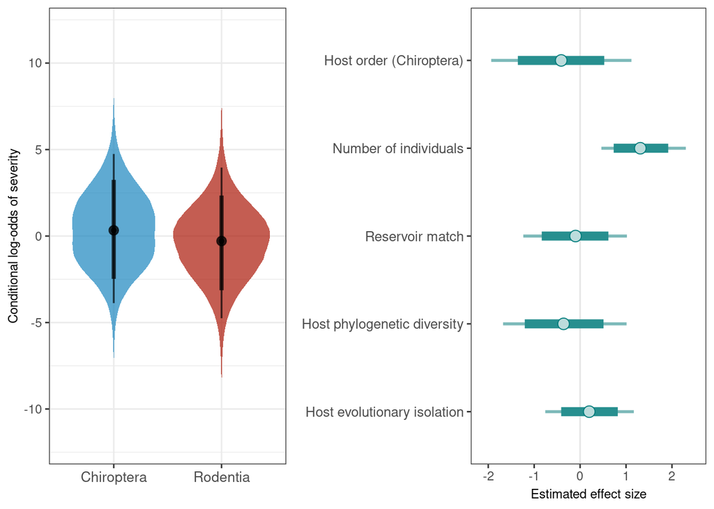

```r
p3 <- cond_eff_plot(model) + scale_y_continuous(lim=c(-12,12)) +
      ylab("Conditional log-odds of severity") + xlab("") +
      theme(axis.title=element_text(size=9),axis.text.x=element_text(size=10)) +
      scale_x_discrete(limits = c("Chiroptera","Rodentia"))

ar3 <- intervals_plot(model)

plot_grid(p3, ar3, align="h", rel_widths =c(0.7,1))
```

```r
# ggsave("../plots_tables/species_level_severity_resMatch_comboplot.pdf", width=8, height=3)
```

Sample size: 176

### Joint results plots (species level reservoir match models - with HEI)

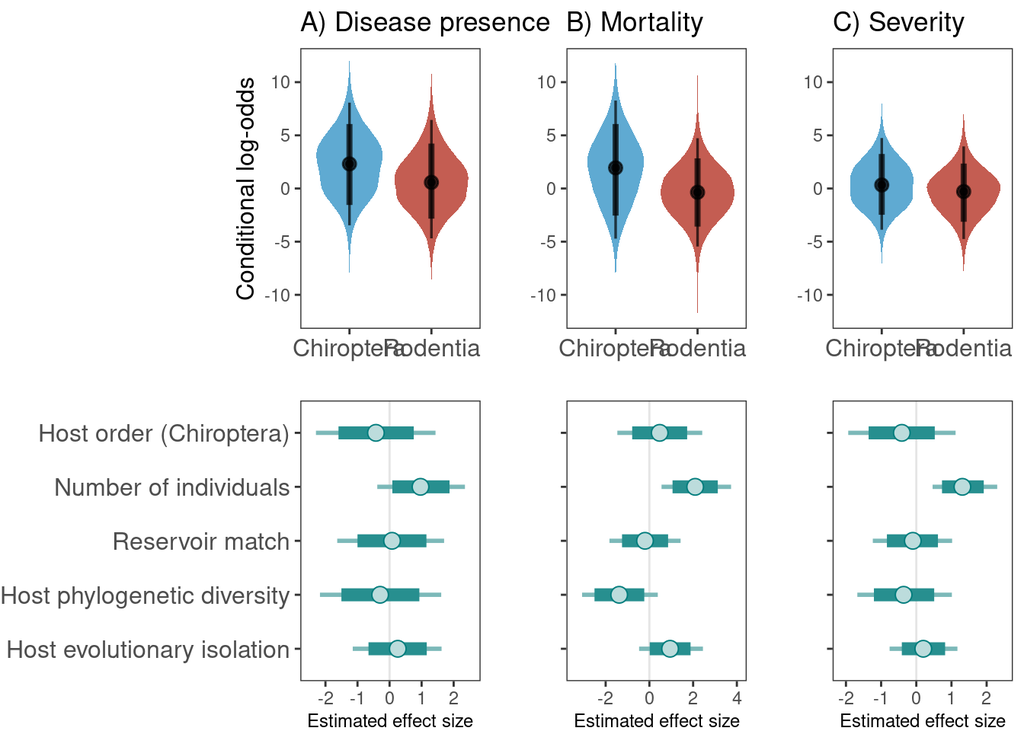

```r
## Joint plot
global_ylim <-  scale_y_continuous(lim=c(-12,12))
padding <- theme(plot.margin = unit(c(t=0, r=-3, b=0, l=0), "cm"))

joint_plot <- joint_conditionals_intervals(p1,p2,p3,global_ylim,padding,ar1,ar2,ar3)
```

```r
ggsave("../plots_tables/species_level_conditionals_intervals_resMatch.pdf", joint_plot, width=10.5, height=5.5)
```

Sample size: 176

### Presence of disease (reservoir match - with HEI and removing Lyssaviruses)

```r
lyssaviruses <- viruses$Virus_ICTV[viruses$genus=="Lyssavirus"] %>% unique()
spec_nolys <- spec[!spec$Virus_ICTV%in%lyssaviruses,]

if (!file.exists("../fit_models/spec_disease_resMatch_nolys.rds")) {

  spec_disease_resMatch_nolys <- brm(Disease_YN ~ Host_order + n_individuals +
                      Reservoir_match + ses_pd + EvoIso +
                      (1|PaperID) +
                      (1|Host_name) + (1|Virus_name) +
                      (1|Host_Upham) + (1|Virus_ICTV),
    data=spec_nolys, family=bernoulli(link = "logit"),
    prior=custom_prior,
    iter=5000, thin=1, cov_ranef = list(Host_Upham = host_cov, Virus_ICTV=virus_cov),
    control=list(adapt_delta=0.90, max_treedepth=12), cores=4,
    save_pars=save_pars(all=TRUE))

  saveRDS(spec_disease_resMatch_nolys, "../fit_models/spec_disease_resMatch_nolys.rds")

} else { spec_disease_resMatch_nolys <- readRDS("../fit_models/spec_disease_resMatch_nolys.rds")}

model <- spec_disease_resMatch_nolys
# summary(model, prob=0.9)

# save memory
rm(spec_disease_resMatch_nolys)

# pp <- brms::posterior_predict(model)
# ppc_dens_overlay(y=model$data$Disease_YN, pp[1:500, ])

param_tab(model)
```

| Parameter | Effects | Mean | CI | CI_low | CI_high | Rhat | Group |
| --- | --- | --- | --- | --- | --- | --- | --- |
| b_Intercept | fixed | 0.95 | 0.90 | -0.43 | 2.35 | 1.00 |  |
| b_Host_orderChiroptera | fixed | -0.53 | 0.90 | -2.05 | 0.99 | 1.00 |  |
| b_n_individuals | fixed | 0.87 | 0.90 | -0.35 | 2.14 | 1.00 |  |
| b_Reservoir_match | fixed | -0.07 | 0.90 | -1.47 | 1.28 | 1.00 |  |
| b_ses_pd | fixed | -0.36 | 0.90 | -2.01 | 1.28 | 1.00 |  |
| b_EvoIso | fixed | 0.39 | 0.90 | -0.80 | 1.57 | 1.00 |  |
| sd_Host_name__Intercept | random | 0.57 | 0.90 | 0.05 | 1.38 | 1.00 | Host_name |
| sd_Host_Upham__Intercept | random | 0.83 | 0.90 | 0.07 | 1.92 | 1.00 | Host_Upham |
| sd_PaperID__Intercept | random | 1.58 | 0.90 | 0.53 | 2.61 | 1.00 | PaperID |
| sd_Virus_ICTV__Intercept | random | 0.83 | 0.90 | 0.07 | 2.00 | 1.00 | Virus_ICTV |
| sd_Virus_name__Intercept | random | 1.31 | 0.90 | 0.20 | 2.48 | 1.00 | Virus_name |

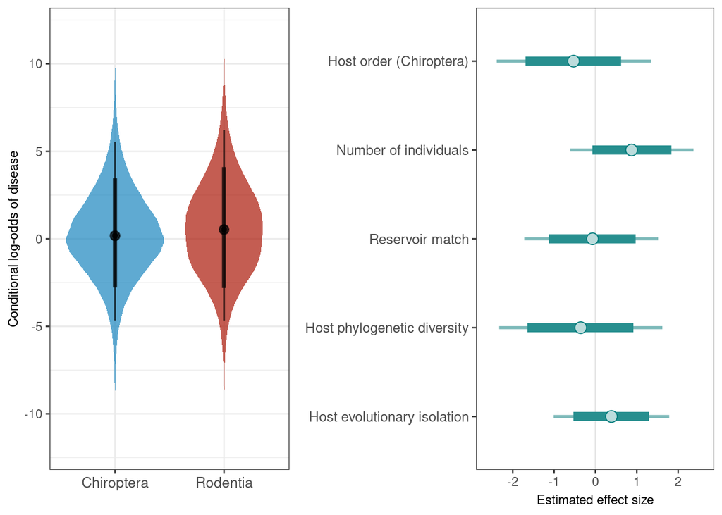

```r
p1 <- cond_eff_plot(model) + scale_y_continuous(lim=c(-12,12)) +
      ylab("Conditional log-odds of disease") + xlab("") +
      theme(axis.title=element_text(size=9),axis.text.x=element_text(size=10)) +
      scale_x_discrete(limits = c("Chiroptera","Rodentia"))

ar1 <- intervals_plot(model)

plot_grid(p1, ar1, align="h", rel_widths =c(0.7,1))
```

```r
# ggsave("../plots_tables/species_level_disease_resMatch_nolys_comboplot.pdf", width=8, height=3)
```

Sample size: 131

### Mortality (reservoir match - with HEI and removing lyssaviruses)

```r
if (!file.exists("../fit_models/spec_mort_resMatch_nolys.rds")) {

  spec_mort_resMatch_nolys <- brm(Mortality_YN ~ Host_order + n_individuals +
                      Reservoir_match + ses_pd + EvoIso +
                      (1|PaperID) +
                      (1|Host_name) + (1|Virus_name) +
                      (1|Host_Upham) + (1|Virus_ICTV),
    data=spec_nolys, family=bernoulli(link = "logit"),
    prior=custom_prior,
    iter=5000, thin=1, cov_ranef = list(Host_Upham = host_cov, Virus_ICTV=virus_cov),
    control=list(adapt_delta=0.90, max_treedepth=12), cores=4,
    save_pars=save_pars(all=TRUE))

  saveRDS(spec_mort_resMatch_nolys, "../fit_models/spec_mort_resMatch_nolys.rds")

} else { spec_mort_resMatch_nolys <- readRDS("../fit_models/spec_mort_resMatch_nolys.rds")}

model <- spec_mort_resMatch_nolys
# summary(model, prob=0.90)

# save memory
rm(spec_mort_resMatch_nolys)

# pp <- brms::posterior_predict(model)
# ppc_dens_overlay(y=model$data$Mortality_YN, pp[1:500, ])

param_tab(model)
```

| Parameter | Effects | Mean | CI | CI_low | CI_high | Rhat | Group |
| --- | --- | --- | --- | --- | --- | --- | --- |
| b_Intercept | fixed | 0.45 | 0.90 | -0.86 | 1.76 | 1.00 |  |
| b_Host_orderChiroptera | fixed | -0.12 | 0.90 | -1.73 | 1.55 | 1.00 |  |
| b_n_individuals | fixed | 1.71 | 0.90 | 0.28 | 3.15 | 1.00 |  |
| b_Reservoir_match | fixed | -0.77 | 0.90 | -2.23 | 0.65 | 1.00 |  |
| b_ses_pd | fixed | -1.47 | 0.90 | -3.10 | 0.24 | 1.00 |  |
| b_EvoIso | fixed | 1.09 | 0.90 | -0.15 | 2.39 | 1.00 |  |
| sd_Host_name__Intercept | random | 0.67 | 0.90 | 0.06 | 1.61 | 1.00 | Host_name |
| sd_Host_Upham__Intercept | random | 0.74 | 0.90 | 0.06 | 1.73 | 1.00 | Host_Upham |
| sd_PaperID__Intercept | random | 1.37 | 0.90 | 0.42 | 2.35 | 1.00 | PaperID |
| sd_Virus_ICTV__Intercept | random | 0.72 | 0.90 | 0.06 | 1.76 | 1.00 | Virus_ICTV |
| sd_Virus_name__Intercept | random | 0.90 | 0.90 | 0.10 | 2.01 | 1.00 | Virus_name |

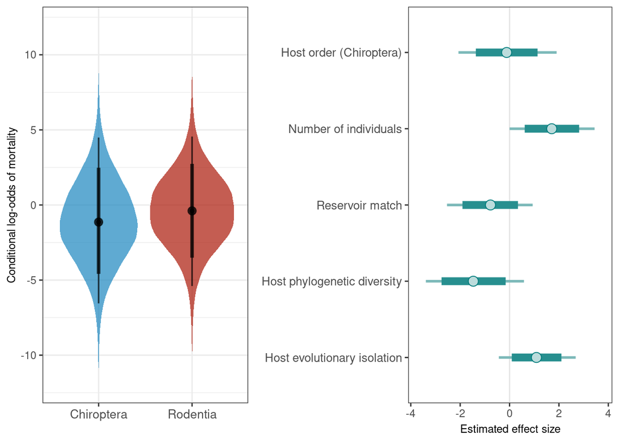

```r
p2 <- cond_eff_plot(model) + scale_y_continuous(lim=c(-12,12)) +
      ylab("Conditional log-odds of mortality") + xlab("") +
      theme(axis.title=element_text(size=9),axis.text.x=element_text(size=10)) +
      scale_x_discrete(limits = c("Chiroptera","Rodentia"))

ar2 <- intervals_plot(model)

plot_grid(p2, ar2, align="h", rel_widths =c(0.7,1))
```

```r
# ggsave("../plots_tables/species_level_mortality_resMatch_nolys_comboplot.pdf", width=8, height=3)
```

Sample size: 98

### Severity (reservoir match - with HEI and removing lyssaviruses)

```r
if (!file.exists("../fit_models/spec_severity_resMatch_nolys.rds")) {

  spec_severity_resMatch_nolys <- brm(severity_rank ~ Host_order + n_individuals +
                      Reservoir_match + ses_pd + EvoIso +
                      (1|PaperID) +
                      (1|Host_name) + (1|Virus_name) +
                      (1|Host_Upham) + (1|Virus_ICTV),
    data=spec_nolys, family=cumulative(probit),
    prior=custom_prior,
    iter=5000, thin=1, cov_ranef = list(Host_Upham = host_cov, Virus_ICTV=virus_cov),
    control=list(adapt_delta=0.95, max_treedepth=12), cores=4,
    save_pars=save_pars(all=TRUE))

  saveRDS(spec_severity_resMatch_nolys, "../fit_models/spec_severity_resMatch_nolys.rds")

} else { spec_severity_resMatch_nolys <- readRDS("../fit_models/spec_severity_resMatch_nolys.rds")}

model <- spec_severity_resMatch_nolys
# summary(model, prob=0.90)

# save memory
rm(spec_severity_resMatch_nolys)

# pp <- brms::posterior_predict(model)
# ppc_dens_overlay(y=model$data$severity_rank, pp[1:500, ])

param_tab(model)
```

| Parameter | Effects | Mean | CI | CI_low | CI_high | Rhat | Group |
| --- | --- | --- | --- | --- | --- | --- | --- |
| b_Intercept[1] | fixed | -1.10 | 0.90 | -2.08 | -0.14 | 1.00 |  |
| b_Intercept[2] | fixed | -0.72 | 0.90 | -1.68 | 0.23 | 1.00 |  |
| b_Intercept[3] | fixed | -0.40 | 0.90 | -1.34 | 0.56 | 1.00 |  |
| b_Intercept[4] | fixed | 0.26 | 0.90 | -0.69 | 1.22 | 1.00 |  |
| b_Host_orderChiroptera | fixed | -0.52 | 0.90 | -1.80 | 0.80 | 1.00 |  |
| b_n_individuals | fixed | 1.03 | 0.90 | 0.22 | 1.90 | 1.00 |  |
| b_Reservoir_match | fixed | -0.25 | 0.90 | -1.24 | 0.71 | 1.00 |  |
| b_ses_pd | fixed | -0.78 | 0.90 | -2.05 | 0.47 | 1.00 |  |
| b_EvoIso | fixed | 0.30 | 0.90 | -0.51 | 1.11 | 1.00 |  |
| sd_Host_name__Intercept | random | 0.62 | 0.90 | 0.05 | 1.49 | 1.01 | Host_name |
| sd_Host_Upham__Intercept | random | 0.83 | 0.90 | 0.09 | 1.76 | 1.00 | Host_Upham |
| sd_PaperID__Intercept | random | 0.92 | 0.90 | 0.44 | 1.49 | 1.00 | PaperID |
| sd_Virus_ICTV__Intercept | random | 0.58 | 0.90 | 0.04 | 1.49 | 1.00 | Virus_ICTV |
| sd_Virus_name__Intercept | random | 1.06 | 0.90 | 0.24 | 1.85 | 1.00 | Virus_name |

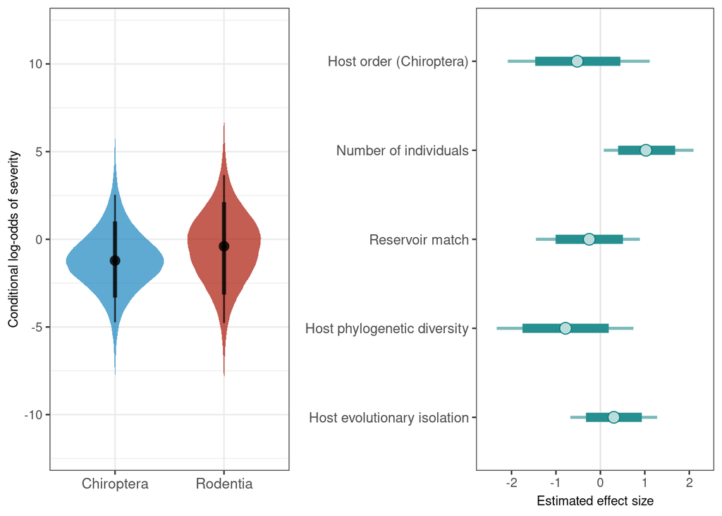

```r
p3 <- cond_eff_plot(model) + scale_y_continuous(lim=c(-12,12)) +
      ylab("Conditional log-odds of severity") + xlab("") +
      theme(axis.title=element_text(size=9),axis.text.x=element_text(size=10)) +
      scale_x_discrete(limits = c("Chiroptera","Rodentia"))

ar3 <- intervals_plot(model)

plot_grid(p3, ar3, align="h", rel_widths =c(0.7,1))
```

```r
# ggsave("../plots_tables/species_level_severity_resMatch_nolys_comboplot.pdf", width=8, height=3)
```

Sample size: 131

### Joint results plots (species level reservoir match models - with HEI and removing lyssaviruses)

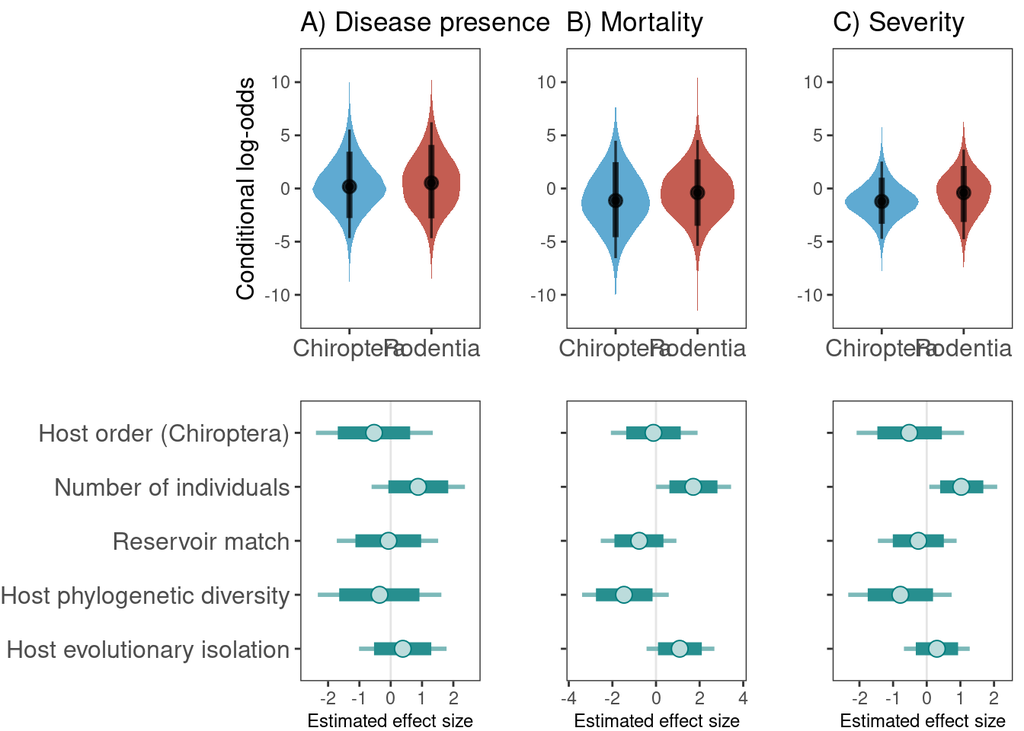

```r
## Joint plot
global_ylim <-  scale_y_continuous(lim=c(-12,12))
padding <- theme(plot.margin = unit(c(t=0, r=-3, b=0, l=0), "cm"))

joint_plot <- joint_conditionals_intervals(p1,p2,p3,global_ylim,padding,ar1,ar2,ar3)
```

```r
ggsave("../plots_tables/species_level_conditionals_intervals_resMatch_nolys.pdf", joint_plot, width=10.5, height=5.5)
```

Sample size: 131

## Species-level models (reservoir match x order interaction)

### Presence of disease (reservoir match x order interaction)

```r
if (!file.exists("../fit_models/spec_disease_resMatch_inter.rds")) {

  disease_resMatch_inter <- brm(Disease_YN ~ Host_order * Reservoir_match + n_individuals +
                      ses_pd + EvoIso +
                      (1|PaperID) +
                      (1|Host_name) + (1|Virus_name) +
                      (1|Host_Upham) + (1|Virus_ICTV),
    data=spec, family=bernoulli(link = "logit"),
    prior=custom_prior,
    iter=5000, thin=1, cov_ranef = list(Host_Upham = host_cov, Virus_ICTV=virus_cov),
    control=list(adapt_delta=0.95, max_treedepth=12), cores=4,
    save_pars=save_pars(all=TRUE))

  saveRDS(disease_resMatch_inter, "../fit_models/spec_disease_resMatch_inter.rds")

} else { disease_resMatch_inter <- readRDS("../fit_models/spec_disease_resMatch_inter.rds")}

model <- disease_resMatch_inter
# summary(model, prob=0.9)

# save memory
rm(disease_resMatch_inter)

# pp <- brms::posterior_predict(model)
# ppc_dens_overlay(y=model$data$Disease_YN, pp[1:500, ])

param_tab(model)
```

| Parameter | Effects | Mean | CI | CI_low | CI_high | Rhat | Group |
| --- | --- | --- | --- | --- | --- | --- | --- |
| b_Intercept | fixed | 0.99 | 0.90 | -0.56 | 2.62 | 1.00 |  |
| b_Host_orderChiroptera | fixed | -0.48 | 0.90 | -2.08 | 1.11 | 1.00 |  |
| b_Reservoir_match | fixed | 8.90e-04 | 0.90 | -1.50 | 1.48 | 1.00 |  |
| b_n_individuals | fixed | 0.97 | 0.90 | -0.14 | 2.12 | 1.00 |  |
| b_ses_pd | fixed | -0.30 | 0.90 | -1.86 | 1.31 | 1.00 |  |
| b_EvoIso | fixed | 0.28 | 0.90 | -0.92 | 1.47 | 1.00 |  |
| b_Host_orderChiroptera:Reservoir_match | fixed | 0.25 | 0.90 | -1.62 | 2.09 | 1.00 |  |
| sd_Host_name__Intercept | random | 0.57 | 0.90 | 0.05 | 1.34 | 1.00 | Host_name |
| sd_Host_Upham__Intercept | random | 0.82 | 0.90 | 0.08 | 1.85 | 1.00 | Host_Upham |
| sd_PaperID__Intercept | random | 1.46 | 0.90 | 0.44 | 2.44 | 1.00 | PaperID |
| sd_Virus_ICTV__Intercept | random | 1.51 | 0.90 | 0.23 | 2.84 | 1.00 | Virus_ICTV |
| sd_Virus_name__Intercept | random | 1.21 | 0.90 | 0.15 | 2.36 | 1.00 | Virus_name |

```r
# source('./scaling_plotting_functions.R')

# test <- plot_conditional_effects(model, "Conditional probabilty of disease presence")
# test

ggsave("../plots_tables/spec_disease_resMatch_inter_cond_effs.pdf", width=6.5, height=5)


# ggsave("../plots_tables/spec_level_disease_resMatch_inter_comboplot.pdf", width=8, height=3)
```

Sample size: 176

### Mortality (reservoir match x order interaction)

```r
if (!file.exists("../fit_models/spec_mortality_resMatch_inter.rds")) {

  mortality_resMatch_inter <- brm(Mortality_YN ~ Host_order * Reservoir_match + n_individuals +
                      ses_pd + EvoIso +
                      (1|PaperID) +
                      (1|Host_name) + (1|Virus_name) +
                      (1|Host_Upham) + (1|Virus_ICTV),
    data=spec, family=bernoulli(link = "logit"),
    prior=custom_prior,
    iter=5000, thin=1, cov_ranef = list(Host_Upham = host_cov, Virus_ICTV=virus_cov),
    control=list(adapt_delta=0.95, max_treedepth=12), cores=4,
    save_pars=save_pars(all=TRUE))

  saveRDS(mortality_resMatch_inter, "../fit_models/spec_mortality_resMatch_inter.rds")

} else { mortality_resMatch_inter <- readRDS("../fit_models/spec_mortality_resMatch_inter.rds")}

model <- mortality_resMatch_inter
# summary(model, prob=0.9)

# save memory
rm(mortality_resMatch_inter)

param_tab(model)
```

| Parameter | Effects | Mean | CI | CI_low | CI_high | Rhat | Group |
| --- | --- | --- | --- | --- | --- | --- | --- |
| b_Intercept | fixed | 0.13 | 0.90 | -1.28 | 1.52 | 1.00 |  |
| b_Host_orderChiroptera | fixed | 0.42 | 0.90 | -1.25 | 2.10 | 1.00 |  |
| b_Reservoir_match | fixed | -0.25 | 0.90 | -1.70 | 1.20 | 1.00 |  |
| b_n_individuals | fixed | 2.11 | 0.90 | 0.80 | 3.45 | 1.00 |  |
| b_ses_pd | fixed | -1.39 | 0.90 | -2.82 | 0.07 | 1.00 |  |
| b_EvoIso | fixed | 0.96 | 0.90 | -0.27 | 2.23 | 1.00 |  |
| b_Host_orderChiroptera:Reservoir_match | fixed | 0.15 | 0.90 | -1.64 | 1.93 | 1.00 |  |
| sd_Host_name__Intercept | random | 0.76 | 0.90 | 0.06 | 1.74 | 1.00 | Host_name |
| sd_Host_Upham__Intercept | random | 0.95 | 0.90 | 0.11 | 1.97 | 1.00 | Host_Upham |
| sd_PaperID__Intercept | random | 1.23 | 0.90 | 0.28 | 2.20 | 1.00 | PaperID |
| sd_Virus_ICTV__Intercept | random | 0.81 | 0.90 | 0.07 | 1.97 | 1.00 | Virus_ICTV |
| sd_Virus_name__Intercept | random | 0.95 | 0.90 | 0.09 | 2.06 | 1.00 | Virus_name |

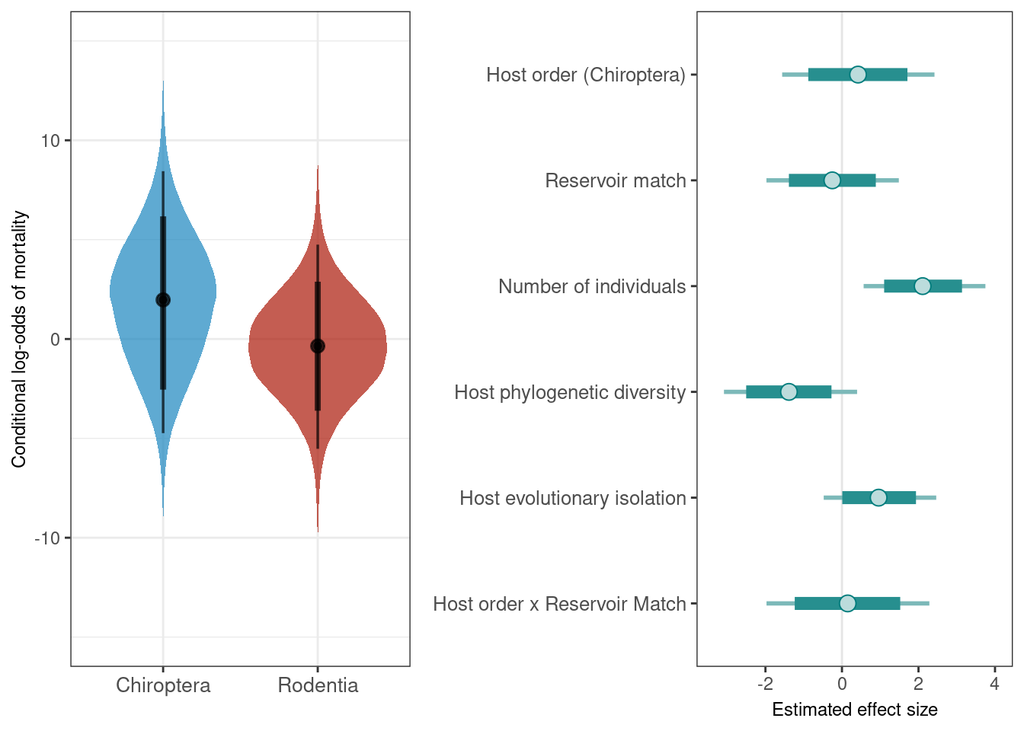

```r
# pp <- brms::posterior_predict(model)
# ppc_dens_overlay(y=model$data$Mortality_YN, pp[1:500, ])

p2 <- cond_eff_plot(model) + scale_y_continuous(lim=c(-15,15)) +
      ylab("Conditional log-odds of mortality") + xlab("") +
      theme(axis.title=element_text(size=9),axis.text.x=element_text(size=10)) +
      scale_x_discrete(limits = c("Chiroptera","Rodentia"))

ar2 <- intervals_plot(model)

plot_grid(p2, ar2, align="h", rel_widths =c(0.7,1))
```

```r
# ggsave("../plots_tables/spec_level_mortality_resMatch_inter_comboplot.pdf", width=8, height=3)
```

Sample size: 139

### Severity (reservoir match x order interaction)

```r
if (!file.exists("../fit_models/spec_severity_resMatch_inter.rds")) {

  severity_resMatch_inter <- brm(severity_rank ~ Host_order * Reservoir_match + n_individuals +
                      ses_pd + EvoIso +
                      (1|PaperID) +
                      (1|Host_name) + (1|Virus_name) +
                      (1|Host_Upham) + (1|Virus_ICTV),
    data=spec, family=cumulative(probit),
    prior=custom_prior,
    iter=5000, thin=1, cov_ranef = list(Host_Upham = host_cov, Virus_ICTV=virus_cov),
    control=list(adapt_delta=0.98, max_treedepth=12), cores=4,
    save_pars=save_pars(all=TRUE))

  saveRDS(severity_resMatch_inter, "../fit_models/spec_severity_resMatch_inter.rds")

} else { severity_resMatch_inter <- readRDS("../fit_models/spec_severity_resMatch_inter.rds")}

model <- severity_resMatch_inter
# summary(model, prob=0.9)

# save memory
rm(severity_resMatch_inter)

# pp <- brms::posterior_predict(model)
# ppc_dens_overlay(y=model$data$severity_rank, pp[1:500, ])

param_tab(model)
```

| Parameter | Effects | Mean | CI | CI_low | CI_high | Rhat | Group |
| --- | --- | --- | --- | --- | --- | --- | --- |
| b_Intercept[1] | fixed | -1.04 | 0.90 | -2.17 | 0.06 | 1.00 |  |
| b_Intercept[2] | fixed | -0.69 | 0.90 | -1.80 | 0.40 | 1.00 |  |
| b_Intercept[3] | fixed | -0.37 | 0.90 | -1.47 | 0.73 | 1.00 |  |
| b_Intercept[4] | fixed | 0.41 | 0.90 | -0.71 | 1.54 | 1.00 |  |
| b_Host_orderChiroptera | fixed | -0.43 | 0.90 | -1.75 | 0.91 | 1.00 |  |
| b_Reservoir_match | fixed | -0.15 | 0.90 | -1.29 | 0.97 | 1.00 |  |
| b_n_individuals | fixed | 1.34 | 0.90 | 0.60 | 2.16 | 1.00 |  |
| b_ses_pd | fixed | -0.37 | 0.90 | -1.51 | 0.74 | 1.00 |  |
| b_EvoIso | fixed | 0.22 | 0.90 | -0.57 | 0.99 | 1.00 |  |
| b_Host_orderChiroptera:Reservoir_match | fixed | 0.10 | 0.90 | -1.34 | 1.51 | 1.00 |  |
| sd_Host_name__Intercept | random | 0.67 | 0.90 | 0.07 | 1.45 | 1.00 | Host_name |
| sd_Host_Upham__Intercept | random | 0.80 | 0.90 | 0.08 | 1.67 | 1.00 | Host_Upham |
| sd_PaperID__Intercept | random | 0.94 | 0.90 | 0.46 | 1.47 | 1.00 | PaperID |
| sd_Virus_ICTV__Intercept | random | 1.15 | 0.90 | 0.19 | 2.17 | 1.00 | Virus_ICTV |
| sd_Virus_name__Intercept | random | 0.94 | 0.90 | 0.13 | 1.79 | 1.00 | Virus_name |

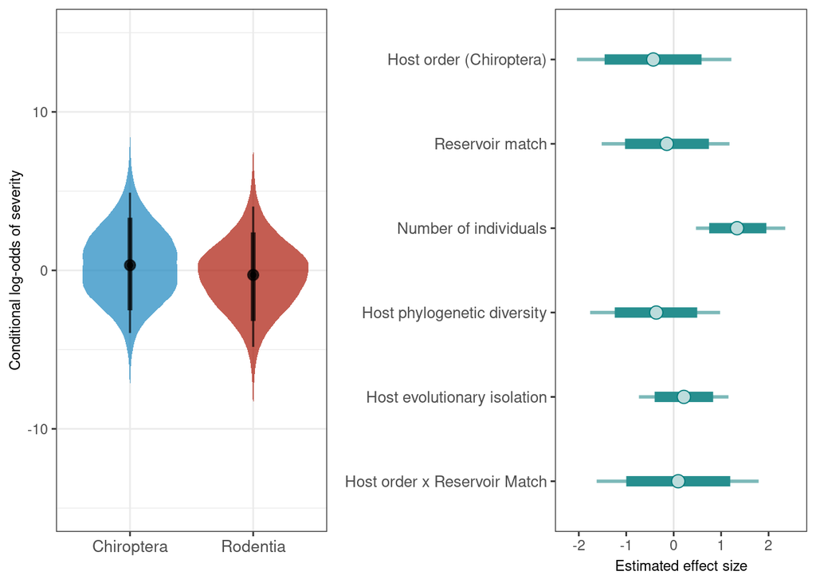

```r
p3 <- cond_eff_plot(model) + scale_y_continuous(lim=c(-15,15)) +
      ylab("Conditional log-odds of severity") + xlab("") +
      theme(axis.title=element_text(size=9),axis.text.x=element_text(size=10)) +
      scale_x_discrete(limits = c("Chiroptera","Rodentia"))

ar3 <- intervals_plot(model)

plot_grid(p3, ar3, align="h", rel_widths =c(0.7,1))
```

```r
# ggsave("../plots_tables/spec_level_severity_resMatch_inter_comboplot.pdf", width=8, height=3)
```

Sample size: 176